# Creating object

## Objective

Create a single cell / Seurat object for analysis

## Set-up

Load required library

```r
library(scater)
library(DropletUtils)
library(Seurat)
library(patchwork)
library(ggplot2)
library(dplyr)
library(reshape2)
library(ggbeeswarm)
library(gghighlight)
library(Matrix)
library(schex)
```

Specify the work space

```r
workDir <- getwd()
workDir <- gsub("/scripts", "", workDir)
dataDir <- file.path(workDir, "data")
outDir <- file.path(workDir, "output")

# out data
outData_dir <- file.path(outDir, "out_data")

outDir_cur <- file.path(outDir, "Chapter_02_Filtering")
dir.create(outDir_cur)
set.seed(100)

source(file.path(workDir, "functions.R"))
```

## In-house Nova

Create sc object (NovaSeq)

Generate the single cell object

```r
nova.sce <- DropletUtils::read10xCounts(file.path(dataDir, "pheonix/NovaSeq/filtered"))
se <- nova.sce
```

To annotate the genes further, we import the GTF file

```r
simple_gtf <- read.delim(file.path(outDir, "out_data/simple_gtf.txt"))

# Combine GTF with sc object
simple_gtf_sub <- simple_gtf %>%
  select(gene_id, gene_type, seqnames)
rD <- rowData(se) %>%
  as.data.frame() %>%
  left_join(simple_gtf_sub, by = c("ID" = "gene_id"))
```

Add cell metaData

```r
mData_full <- read.csv(file.path(outDir, "Chapter_01_Preprocessing/NovaSeq_full.csv"))
mData <- read.csv(file.path(outDir, "Chapter_01_Preprocessing/NovaSeq_selected.csv")) %>%
  dplyr::select(-X, -V1)

# Combine with cell annotation
cD <- colData(se) %>%
  as.data.frame() %>%
  left_join(mData, by = c("Barcode" = "CellID")) %>%
  dplyr::select(-Sample)
```

There will be some NA generated. These are from cells that we have excluded in our analysis, but we quantified them anyway

```r
nacells <- cD[is.na(cD$condition), ] %>%
  pull(Barcode)

mData_full_sub <- mData_full %>%
  filter(CellID %in% nacells)
table(mData_full_sub$condition)
```

```
##
## Roshana   Steve
##      30      85
```

Add new colData and rowData to se object

```r
colData(se) <- DataFrame(cD)
rowData(se) <- DataFrame(rD)
```

Remove the un-interested population

```r
se <- se[,!is.na(se$condition)]
```

Convert the population (condition) as factors

```r
se$condition <- factor(se$condition, levels=nova_popFac)
```

### Filtering low-quality cells

Our first aim is to remove low-quality cells. For all of the run, we apply a threshold to filter the cells. We will use the follwoing

- Number of genes detected
- Percentage of Mitochondira reads
- Percentage of Hemoglobin (Hbb) genes

Find the QC of specific genes

```r
# Specific the location
MT_gene <- rD$seqnames == "chrM"
Hbbs <- rD[grepl("Hb[a-b]", rD$Symbol),] %>% pull(Symbol)
Hbbs <- c(Hbbs, "Gypa")
#Hbbs <- c("Hba-x", "Hbb-bh1", "Hbb-y", "Hba-a1")

# Get the Ens ID
Hb_ens <- rD %>%
  dplyr::filter(Symbol %in% Hbbs)
Hbb_gene <- rowData(se)$ID %in% Hb_ens$ID
```

We examine the distibution of the data in all the run

```r
df_cData <-
  perCellQCMetrics(se,
                   subsets=list(Mito=MT_gene,
                                Hbb=Hbb_gene)) %>%
  cbind(as.data.frame(colData(se))) %>%
  as.data.frame() %>%
  dplyr::mutate(Cell = colnames(se))


# To plot select a subset of columns
df_cData_sub <- as.data.frame(df_cData) %>%
  #tibble::rownames_to_column(var = "Cell") %>%
  dplyr::select(Barcode, sum, detected, subsets_Mito_percent, subsets_Hbb_percent, condition)

m <- melt(df_cData_sub)
```

Plot the distribution

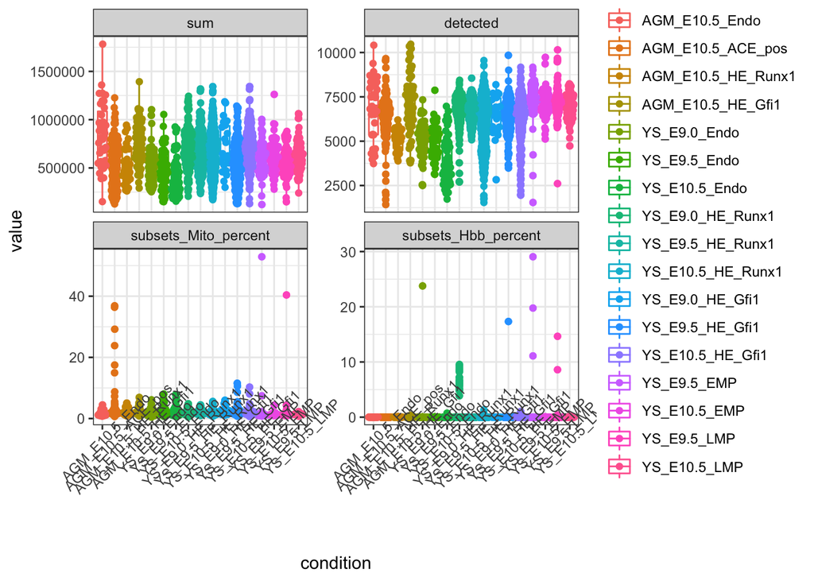

```r
ggplot(m, aes(x=condition, y=value, colour=condition)) +
  geom_boxplot(aes(),fill=NA) +
  geom_quasirandom(dodge.width=0.75) +
  theme_bw()  +
  facet_wrap(~variable, scales = "free_y") +
  theme(axis.text.x = element_text(angle = 45)) +
  NULL
```

Lets apply a cut-off

```r
df_cData_fil <- df_cData_sub %>%
  dplyr::filter(
    detected > 2000,
    subsets_Mito_percent < 15,
    subsets_Hbb_percent < 10)
```

Subset the sc object

```r
se <- se[,se$Barcode %in% df_cData_fil$Barcode]
```

### Filtering lowly-expressed genes

> To do, there is no filtering of lowly-expresed genes in Seurat?

### Convert to gene symbol

To enable a user-friendly analysis, it is convenient to exchange the ENSEMBL IDs with the name of the genes.

For duplicated gene names, we merge them with the ENSEMBL IDs to avoid confusion.

```r
new.row.names <- uniquifyFeatureNames(
    rowData(se)$ID,
    rowData(se)$Symbol
)

rownames(se) <- new.row.names
head(rownames(se), 5)
```

```
## [1] "Xkr4"    "Gm1992"  "Gm19938" "Gm37381" "Rp1"
```

```r
se_nova <- se
```

### Quick seurat

```r
colnames(se) <- se$Barcode
seu <-
  Seurat::CreateSeuratObject(counts = assay(se, "counts"),
                     project = "NovaSeq",
                     meta.data = as.data.frame(colData(se)),
                     min.cells = 3, min.features = 200)
# Colour scheme
#pal.pop2_sub <- df_pal_pop2 %>%
#  dplyr::filter(Population %in% se2$condition) %>% pull(Col)


seuset <- NormalizeData(
  object = seu,
  normalization.method = "LogNormalize",
  scale.factor = 10000
)
# Feature selections
seuset <-
  FindVariableFeatures(object = seuset, selection.method = "vst", nfeatures = 2500)
# Scaling the data
all.genes <- rownames(x = seuset)
seuset <- ScaleData(object = seuset, features = all.genes)
```

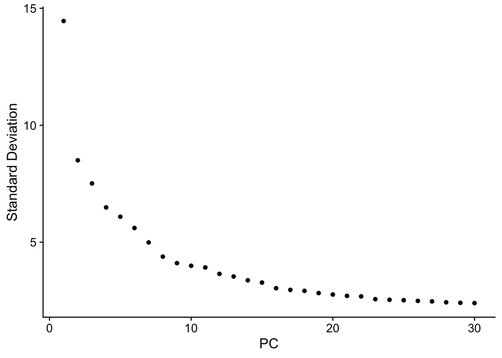

```r
# These are now standard steps in the Seurat workflow for visualization and clustering
seuset <- RunPCA(seuset, verbose = FALSE)
ElbowPlot(object = seuset, ndims = 30)
```

```r
seuset <- RunUMAP(seuset, dims = 1:30, verbose = FALSE)
seuset <- FindNeighbors(seuset, dims = 1:30, verbose = FALSE)
seuset <- FindClusters(seuset, verbose = FALSE)

seuset_nova <- seuset
```

#### UMAP visualisation

Extract the UMAP dimension

```r
umap.df <- as.data.frame(Embeddings(object = seuset, reduction = "umap")) %>%
  tibble::rownames_to_column(var="Cell") %>%
  cbind(seuset[[]])


# Subset based on sorted population
p1 <-
  ggplot(umap.df, aes(x=UMAP_1, y=UMAP_2, colour=condition)) +
  geom_point() +
  gghighlight(use_direct_label = FALSE) +
  theme(legend.position = "right") +
  facet_wrap(~condition) +
  theme_bw() +
  #scale_colour_manual(values=pal.pop2_sub) +
  labs(title="Highlighting the FACS clusters in combined data")

png(file.path(outDir_cur, "Nova_UMAP.png"), width=1200, height=900)
p1
dev.off()
```

## In-house Next

Generate the single cell object

```r
next.sce <- DropletUtils::read10xCounts(file.path(dataDir, "pheonix/NextSeq/filtered"))
se <- next.sce
```

To annotate the genes further, we import the GTF file

```r
# Combine GTF with sc object
simple_gtf_sub <- simple_gtf %>%
  select(gene_id, gene_type, seqnames)
rD <- rowData(se) %>%
  as.data.frame() %>%
  left_join(simple_gtf_sub, by = c("ID" = "gene_id"))
```

Add cell metaData

```r
mData_full <- read.csv(file.path(outDir, "Chapter_01_Preprocessing/NextSeq_full.csv"))
mData <- read.csv(file.path(outDir, "Chapter_01_Preprocessing/NextSeq_selected.csv")) %>%
  dplyr::select(-X)

# Combine with cell annotation
cD <- colData(se) %>%
  as.data.frame() %>%
  left_join(mData, by = c("Barcode" = "CellID")) %>%
  dplyr::select(-Sample)
```

There will be some NA generated. These are from cells that we have excluded in our analysis, but we quantified them anyway

```r
nacells <- cD[is.na(cD$condition), ] %>%
  pull(Barcode)

mData_full_sub <- mData_full %>%
  filter(CellID %in% nacells)
table(mData_full_sub$condition)
```

```
##
## AGM_E10.5_Endo_Runx1_KO       AGM_E10.5_HE_Gfi1    AGM_E10.5_HE_Gfis_KO
##                      12                      19                      40
##   AGM_E10.5_HE_Runx1_KO           AGM_E11.5_EHT          AGM_E11.5_Endo
##                     269                      38                      53
##       AGM_E11.5_HE_Gfi1          AGM_E11.5_IAHC      MES_E10.5_Runx1_KO
##                      85                      53                      82
##          YS_E10_HE_Gfi1         YS_E7.5_GPP_neg         YS_E7.5_GPP_pos
##                      32                      60                       5
```

> Maybe we want to exclude Runx1 KO too, leave it for now

Add new colData and rowData to se object

```r
colData(se) <- DataFrame(cD)
rowData(se) <- DataFrame(rD)
```

Remove the un-interested population

```r
se <- se[,!is.na(se$condition)]
```

Convert the population (condition) as factors

```r
se$condition <- factor(se$condition, levels=next_popFac)
```

### Filtering low-quality cells

Our first aim is to remove low-quality cells. For all of the run, we apply a threshold to filter the cells. We will use the follwoing

- Number of genes detected
- Percentage of Mitochondira reads
- Percentage of Hemoglobin (Hbb) genes

Find the QC of specific genes

```r
# Specific the location
MT_gene <- rD$seqnames == "chrM"
Hbbs <- rD[grepl("Hb[a-b]", rD$Symbol),] %>% pull(Symbol)
Hbbs <- c(Hbbs, "Gypa")
#Hbbs <- c("Hba-x", "Hbb-bh1", "Hbb-y", "Hba-a1")

# Get the Ens ID
Hb_ens <- rD %>%
  dplyr::filter(Symbol %in% Hbbs)
Hbb_gene <- rowData(se)$ID %in% Hb_ens$ID
```

We examine the distibution of the data in all the run

```r
df_cData <-
  perCellQCMetrics(se,
                   subsets=list(Mito=MT_gene,
                                Hbb=Hbb_gene)) %>%
  cbind(as.data.frame(colData(se))) %>%
  as.data.frame() %>%
  dplyr::mutate(Cell = colnames(se))


# To plot select a subset of columns
df_cData_sub <- as.data.frame(df_cData) %>%
  #tibble::rownames_to_column(var = "Cell") %>%
  dplyr::select(Barcode, sum, detected, subsets_Mito_percent, subsets_Hbb_percent, condition)

m <- melt(df_cData_sub)
```

Plot the distribution

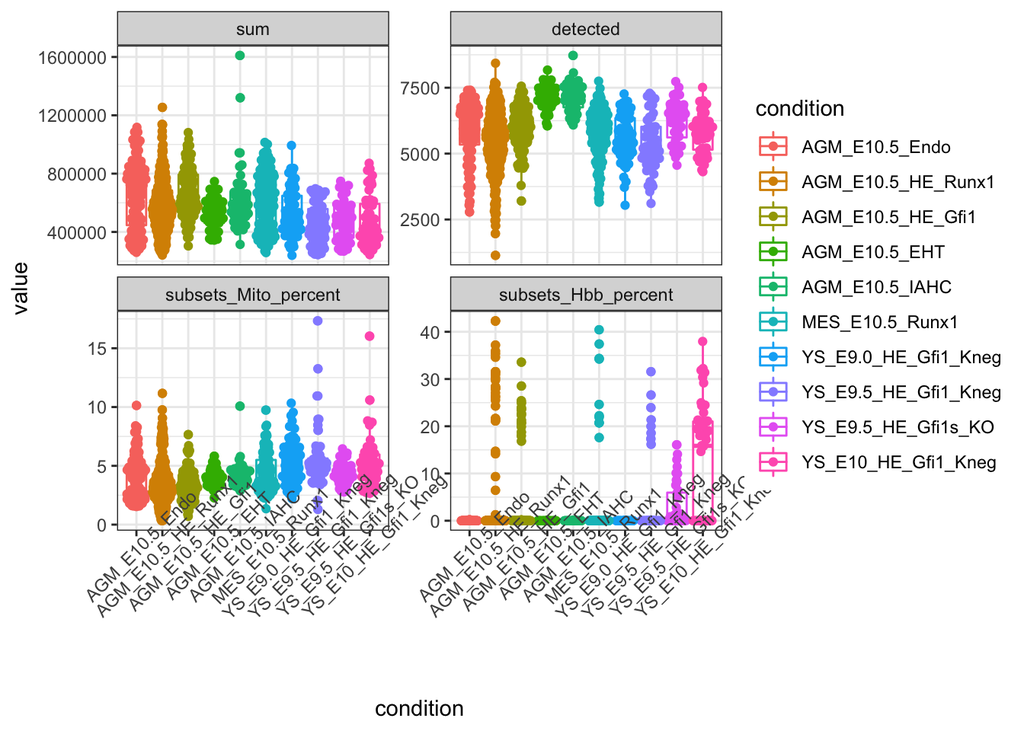

```r
ggplot(m, aes(x=condition, y=value, colour=condition)) +
  geom_boxplot(aes(),fill=NA) +
  geom_quasirandom(dodge.width=0.75) +
  theme_bw()  +
  facet_wrap(~variable, scales = "free_y") +
  theme(axis.text.x = element_text(angle = 45)) +
  NULL
```

Lets apply a cut-off

```r
df_cData_fil <- df_cData_sub %>%
  dplyr::filter(
    detected > 2000,
    subsets_Mito_percent < 15,
    subsets_Hbb_percent < 10)
```

Subset the sc object

```r
se <- se[,se$Barcode %in% df_cData_fil$Barcode]
```

### Filtering lowly-expressed genes

> To do, there is no filtering of lowly-expresed genes in Seurat?

### Convert to gene symbol

To enable a user-friendly analysis, it is convenient to exchange the ENSEMBL IDs with the name of the genes.

For duplicated gene names, we merge them with the ENSEMBL IDs to avoid confusion.

```r
new.row.names <- uniquifyFeatureNames(
    rowData(se)$ID,
    rowData(se)$Symbol
)

rownames(se) <- new.row.names
head(rownames(se), 5)
```

```
## [1] "Xkr4"    "Gm1992"  "Gm19938" "Gm37381" "Rp1"
```

```r
se_next <- se
```

### Quick seurat

```r
colnames(se) <- se$Barcode
seu <-
  Seurat::CreateSeuratObject(counts = assay(se, "counts"),
                     project = "NextSeq",
                     meta.data = as.data.frame(colData(se)),
                     min.cells = 3, min.features = 200)
# Colour scheme
#pal.pop2_sub <- df_pal_pop2 %>%
#  dplyr::filter(Population %in% se2$condition) %>% pull(Col)


seuset <- NormalizeData(
  object = seu,
  normalization.method = "LogNormalize",
  scale.factor = 10000
)
# Feature selections
seuset <-
  FindVariableFeatures(object = seuset, selection.method = "vst", nfeatures = 2500)
# Scaling the data
all.genes <- rownames(x = seuset)
seuset <- ScaleData(object = seuset, features = all.genes)
```

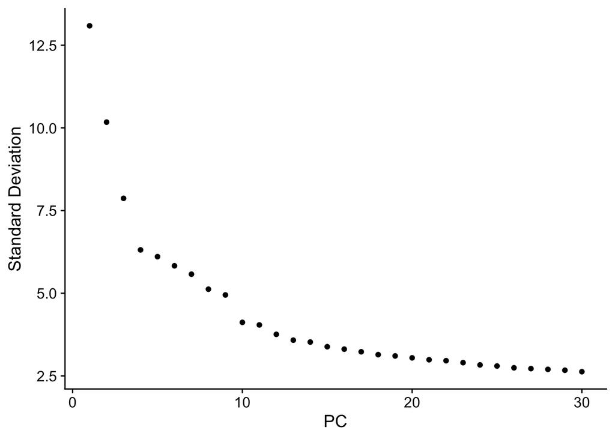

```r
# These are now standard steps in the Seurat workflow for visualization and clustering
seuset <- RunPCA(seuset, verbose = FALSE)
ElbowPlot(object = seuset, ndims = 30)
```

```r
seuset <- RunUMAP(seuset, dims = 1:30, verbose = FALSE)

seuset <- FindNeighbors(seuset, dims = 1:30, verbose = FALSE)
seuset <- FindClusters(seuset, verbose = FALSE)

seuset_next <- seuset
```

#### UMAP visualisation

Extract the UMAP dimension

```r
umap.df <- as.data.frame(Embeddings(object = seuset, reduction = "umap")) %>%
  tibble::rownames_to_column(var="Cell") %>%
  cbind(seuset[[]])


# Subset based on sorted population
p1 <-
  ggplot(umap.df, aes(x=UMAP_1, y=UMAP_2, colour=condition)) +
  geom_point() +
  gghighlight(use_direct_label = FALSE) +
  theme(legend.position = "right") +
  facet_wrap(~condition) +
  theme_bw() +
  #scale_colour_manual(values=pal.pop2_sub) +
  labs(title="Highlighting the FACS clusters in combined data")


png(file.path(outDir_cur, "Next_UMAP.png"), width=1200, height=900)
p1
dev.off()
```

## Nancy data

```r
outDir_nancy <- file.path(outDir_cur, "Nancy_2020")
dir.create(outDir_nancy)
```

To obtain a more comprehensive representation of E10.5 time-point, lets also use Nancy 10x E10.5 data/ We process Nancy’s data from GEO

We want to only obtain a subset of Nancy’s data. The initial data has 46,048 cells. We need the E10.5 pre-He, HE, and IAC. We do the following cell subset just once and save the output file to conserve RAM memory. The result will leave us with fewer cells

```r
dat <- readMM(file.path(dataDir, "publicData/GEO_dowload/Nancy_2020/GSE137116_gene_by_cell_count_matrix.txt"))

g.anno <-read.csv(file.path(dataDir, "publicData/GEO_dowload/Nancy_2020/GSE137116_gene_annotation.csv"))
c.anno <- read.csv(file.path(dataDir, "publicData/GEO_dowload/Nancy_2020/GSE137116_cell_annotation.csv"))

colnames(dat) <- c.anno$X
rownames(dat) <- g.anno$id

nancy.sce <-
  SingleCellExperiment(
  assays = list(counts = dat),
  colData = c.anno,
  rowData = g.anno)


# Remove ENS genes that is present in Nancy data that is not present in our data
ourGenes <- row.names(nova.sce)
nancyGenes <- row.names(nancy.sce)

nancyGenes_sub <- nancyGenes[nancyGenes %in% ourGenes]


nancy.sce <- nancy.sce[row.names(nancy.sce) %in% nancyGenes_sub,]


new.row.names <- uniquifyFeatureNames(
    rowData(nancy.sce)$id,
    rowData(nancy.sce)$symbol
)
rownames(nancy.sce) <- new.row.names


# We need to do some filtering to select the population of interest
## Remove NA from the population tab
nancy.sce <- nancy.sce[,!is.na(nancy.sce$Cell_type_refined) ]
nancy.sce_ori <- nancy.sce

# Select interested cells from E11.5
df_cell <- as.data.frame(colData(nancy.sce))
## Randomly select 100 from IAC
set.seed(123)
df_E11 <- df_cell %>%
  dplyr::filter(Dataset == "E11.5_CD45+CD27+IAC" & Cell_type_refined == "IAC") %>%
  group_by(Cell_type_refined) %>% slice_sample(n = 100)


# Select interested cells from E10.5
dataInt <- as.character(unique( c.anno$Combined_Dataset[grep("E10.5", c.anno$Combined_Dataset)]))
scATAC_loc <- grep("scATAC", dataInt)
dataInt <- dataInt[-scATAC_loc]
nancy.sce <- nancy.sce[,nancy.sce$Combined_Dataset %in% dataInt]
## Select the populations we are interested in
popInterest <- c("HE", "IAC", "Pre-HE [AE]", "Conflux endo [AE]")
nancy.sce <- nancy.sce[,nancy.sce$Cell_type_refined %in% popInterest]

## We subset cells based on thier sorting gate (Combined Dataset column)
## Randomly select 150 from IAC, 100 cells from Pre-HE and HE and 50 cells from Pre-HE
set.seed(123)
# Remove cells with no pseudotime
df_cell <- as.data.frame(colData(nancy.sce)) %>%
  filter(!is.na(pseudotime_slingshot))
df_cell_1.1  <- df_cell %>%
  filter(Cell_type_refined %in% c("HE") & Combined_Dataset == "E10.5 HE") %>%
  group_by(Cell_type_refined) %>% slice_sample(n = 60) %>%
  pull(X)

df_cell_1.2  <- df_cell %>%
  filter(Cell_type_refined %in% c("HE") & Combined_Dataset == "E10.5 E+HE+IAC") %>%
  group_by(Cell_type_refined) %>% slice_sample(n = 40) %>%
  pull(X)

df_cell_2  <- df_cell %>%
  filter(Cell_type_refined %in% c("Pre-HE [AE]")) %>% #& Combined_Dataset == "E10.5 E+HE+IAC") %>%
  group_by(Cell_type_refined) %>% slice_sample(n = 100) %>%
  pull(X)


df_cell_3  <- df_cell %>%
  filter(Cell_type_refined %in% c("IAC"))  %>%
  group_by(Cell_type_refined) %>% slice_sample(n = 150) %>%
  pull(X)


#df_cell_3.1  <- df_cell %>%
#  filter(Cell_type_refined %in% c("IAC") & Combined_Dataset == "E10.5 E+HE+IAC") %>%
#  group_by(Cell_type_refined) %>% slice_sample(n = 75) %>%
#  pull(X)


#df_cell_3.2  <- df_cell %>%
#  filter(Cell_type_refined %in% c("IAC") & Combined_Dataset == "E10.5 IAC") %>%
#  group_by(Cell_type_refined) %>% slice_sample(n = 75) %>%
#  pull(X)

df_cell_4  <- df_cell %>%
  filter(Cell_type_refined %in% c("Conflux endo [AE]")) %>% #& Combined_Dataset == "E10.5 E+HE+IAC") %>%
  group_by(Cell_type_refined) %>% slice_sample(n = 50) %>%
  pull(X)

interestedCells <- c(df_cell_1.1, df_cell_1.2, df_cell_2,df_cell_3,df_cell_4)
# Subset
nancy.sce <- nancy.sce_ori[,nancy.sce_ori$X %in% c(interestedCells, df_E11$X)]


# Save this object so we need not do the integration again
saveRDS(nancy.sce, file=file.path(outData_dir, "Nancy_filtered.RDS"))
```

#### Normalise

First create Seurat object

```r
se <- readRDS(file.path(outData_dir, "Nancy_filtered.RDS"))
seu <-
  Seurat::CreateSeuratObject(counts = assay(se, "counts"),
                     project = "Nancy",
                     meta.data = as.data.frame(colData(se)),
                     min.cells = 3, min.features = 200)
seuset <- NormalizeData(
  object = seu,
  normalization.method = "LogNormalize",
  scale.factor = 10000
)
# Feature selections
seuset <-
  FindVariableFeatures(object = seuset, selection.method = "vst", nfeatures = 2500)
# Scaling the data
all.genes <- rownames(x = seuset)
seuset <- ScaleData(object = seuset, features = all.genes)
# Cell cycle
s.genes <- cc.genes.updated.2019$s.genes
g2m.genes <- cc.genes.updated.2019$g2m.genes

seuset <- CellCycleScoring(seuset, s.features = s.genes, g2m.features = g2m.genes, set.ident = FALSE)
```

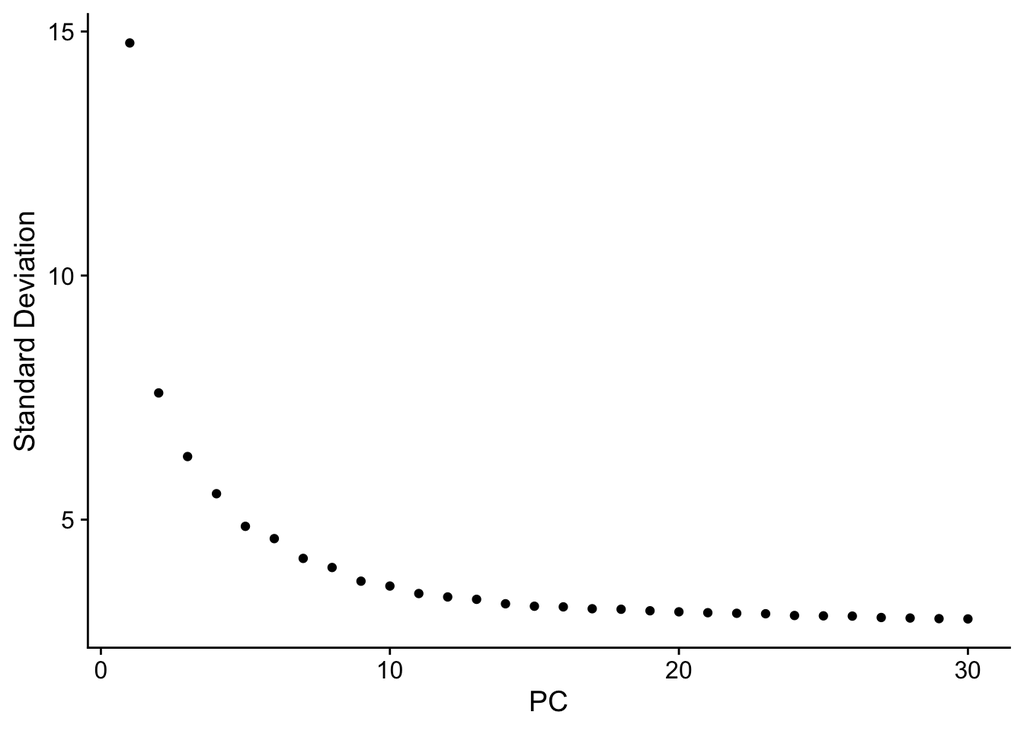

```r
# These are now standard steps in the Seurat workflow for visualization and clustering
seuset <- RunPCA(seuset, verbose = FALSE)
ElbowPlot(object = seuset, ndims = 30)
```

```r
seuset <- RunUMAP(seuset, dims = 1:30, verbose = FALSE)

seuset <- FindNeighbors(seuset, dims = 1:30, verbose = FALSE)
seuset <- FindClusters(seuset, verbose = FALSE,resolution = 1)

seu_nancy <- seuset
```

#### UMAP visualisation

Extract the UMAP dimension

```r
umap.df <- as.data.frame(Embeddings(object = seuset, reduction = "umap")) %>%
  #tibble::rownames_to_column(var="Cell") %>%
  cbind(seuset[[]])


# Subset based on sorted population
p1 <-
  ggplot(umap.df, aes(x=UMAP_1, y=UMAP_2, colour=Combined_Dataset)) +
  geom_point() +
  gghighlight(use_direct_label = FALSE) +
  theme(legend.position = "right") +
  facet_wrap(~Cell_type_refined) +
  theme_bw() +
  #scale_colour_manual(values=pal.pop2_sub) +
  labs(title="Highlighting the cell type population")

p2 <-
  ggplot(umap.df, aes(x=UMAP_1, y=UMAP_2, colour=seurat_clusters)) +
  geom_point() +
  gghighlight(use_direct_label = FALSE) +
  theme(legend.position = "right") +
  facet_wrap(~seurat_clusters) +
  theme_bw() +
  #scale_colour_manual(values=pal.pop2_sub) +
  labs(title="Highlighting the in silico clusters")

png(file.path(outDir_nancy, "UMAP_condition.png"), width=1200, height=900)
p1
dev.off()
```

```r
png(file.path(outDir_nancy, "UMAP_cluster.png"), width=1200, height=900)
p2
dev.off()
```

## Mouse gastrulation data

```r
outDir_Pijuan <- file.path(outDir_cur, "Pijuan_2019")
dir.create(outDir_Pijuan)
```

The orignal publication of this paper is from https://www.nature.com/articles/s41586-019-0933-9. However we downloaded this data from http://tome.gs.washington.edu/

### E8.25 Smart Seq

In the paper they also did Smart-seq2 of 288 Flk1+ cells, from allantions, embyro propoer and yolk sac. We downloaded the fastq files from https://www.ebi.ac.uk/arrayexpress/experiments/E-MTAB-6970/. We processed the fastq files as described in the sections below (Zhou 2016 and Hou 2020 section)

```r
pijuan.sce <- DropletUtils::read10xCounts(file.path(dataDir, "publicData/Pijuan_STARsolo/filtered"))
se <- pijuan.sce


simple_gtf <- read.delim(file.path(outDir, "out_data/simple_gtf.txt"))

# Combine GTF with sc object
simple_gtf_sub <- simple_gtf %>%
  select(gene_id, gene_type, seqnames)
rD <- rowData(se) %>%
  as.data.frame() %>%
  left_join(simple_gtf_sub, by = c("ID" = "gene_id"))
```

Add cell metaData

```r
# Read the file accompanying the sequencing fastq
mData_ebi <- read.delim(file.path(dataDir, "publicData/GEO_dowload/PijuanSala_2019/E-MTAB-6970.sdrf.txt"))
# Read the manifest file used as input to STAR solo
mData_starSolo <- read.delim(file.path(dataDir, "publicData/GEO_dowload/PijuanSala_2019/manifest_PijuanSala.txt"),header=FALSE)

# We need to link the SRA name with the population identifier (eg T1 pre-HSC, T2 pre-HSC) with the name of the cells as named by STARsolo during mapping
mData_1 <- mData_ebi %>%
  dplyr::select(Comment.ENA_RUN., Characteristics.organism.part.) %>%
  dplyr::rename(Site = 'Characteristics.organism.part.',
                Run = 'Comment.ENA_RUN.')
mData_2 <- mData_starSolo %>%
  mutate(Run = gsub(".fastq", "", V1),
         Run = gsub(".*_2019/", "", Run)) %>%
  dplyr::rename(Barcode = V3) %>%
  dplyr::select(Run, Barcode)
mData_comb <- left_join(mData_1, mData_2)
# Combine with cell annotation
cD <- colData(se) %>%
  as.data.frame() %>%
  left_join(mData_comb, by = c("Barcode" = "Barcode")) %>%
  dplyr::select(-Sample) %>%
  dplyr::rename(condition = Site)

# Renomae
NewName <- cD$condition
NewName <- dplyr::case_when(
  NewName == 'yolk sac' ~ "YS_E8.25_Flk_pos",
  NewName == 'embryo' ~ "WE_E8.25_Flk_pos",
  NewName == 'allantois' ~ "Alan_E8.25_Flk_pos"

)
cD$condition <- NewName
```

Add new colData and rowData to se object

```r
colData(se) <- DataFrame(cD)
rowData(se) <- DataFrame(rD)
```

Remove un interesting population

```r
se <- se[,se$condition %in% c("YS_E8.25_Flk_pos", "WE_E8.25_Flk_pos")]
```

Find the QC of specific genes

```r
# Specific the location
MT_gene <- rD$seqnames == "chrM"
Hbbs <- rD[grepl("Hb[a-b]", rD$Symbol),] %>% pull(Symbol)
Hbbs <- c(Hbbs, "Gypa")
#Hbbs <- c("Hba-x", "Hbb-bh1", "Hbb-y", "Hba-a1")

# Get the Ens ID
Hb_ens <- rD %>%
  dplyr::filter(Symbol %in% Hbbs)
Hbb_gene <- rowData(se)$ID %in% Hb_ens$ID
```

We examine the distibution of the data in all the run

```r
df_cData <-
  perCellQCMetrics(se,
                   subsets=list(Mito=MT_gene,
                                Hbb=Hbb_gene)) %>%
  cbind(as.data.frame(colData(se))) %>%
  as.data.frame() %>%
  dplyr::mutate(Cell = colnames(se))


# To plot select a subset of columns
df_cData_sub <- as.data.frame(df_cData) %>%
  #tibble::rownames_to_column(var = "Cell") %>%
  dplyr::select(Barcode, sum, detected, subsets_Mito_percent, subsets_Hbb_percent, condition)

m <- melt(df_cData_sub)
```

Plot the distribution

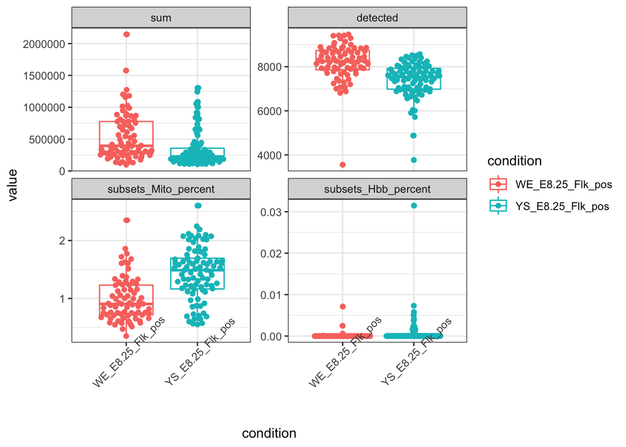

```r
ggplot(m, aes(x=condition, y=value, colour=condition)) +
  geom_boxplot(aes(),fill=NA) +
  geom_quasirandom(dodge.width=0.75) +
  theme_bw()  +
  facet_wrap(~variable, scales = "free_y") +
  theme(axis.text.x = element_text(angle = 45)) +
  NULL
```

#### Filtering lowly-expressed genes

> To do, there is no filtering of lowly-expresed genes in Seurat?

#### Convert to gene symbol

To enable a user-friendly analysis, it is convenient to exchange the ENSEMBL IDs with the name of the genes.

For duplicated gene names, we merge them with the ENSEMBL IDs to avoid confusion.

```r
new.row.names <- uniquifyFeatureNames(
    rowData(se)$ID,
    rowData(se)$Symbol
)

rownames(se) <- new.row.names
head(rownames(se), 5)
```

```
## [1] "Xkr4"    "Gm1992"  "Gm19938" "Gm37381" "Rp1"
```

```r
se_Pijuan <- se
```

#### Quick seurat

```r
colnames(se) <- se$Barcode
seu <-
  Seurat::CreateSeuratObject(counts = assay(se, "counts"),
                     project = "Pijuan",
                     meta.data = as.data.frame(colData(se)),
                     min.cells = 3, min.features = 200)
# Colour scheme
#pal.pop2_sub <- df_pal_pop2 %>%
#  dplyr::filter(Population %in% se2$condition) %>% pull(Col)


seuset <- NormalizeData(
  object = seu,
  normalization.method = "LogNormalize",
  scale.factor = 10000
)
# Feature selections
seuset <-
  FindVariableFeatures(object = seuset, selection.method = "vst", nfeatures = 2500)
# Scaling the data
all.genes <- rownames(x = seuset)
seuset <- ScaleData(object = seuset, features = all.genes)
seuset <- CellCycleScoring(seuset, s.features = s.genes, g2m.features = g2m.genes, set.ident = FALSE)
```

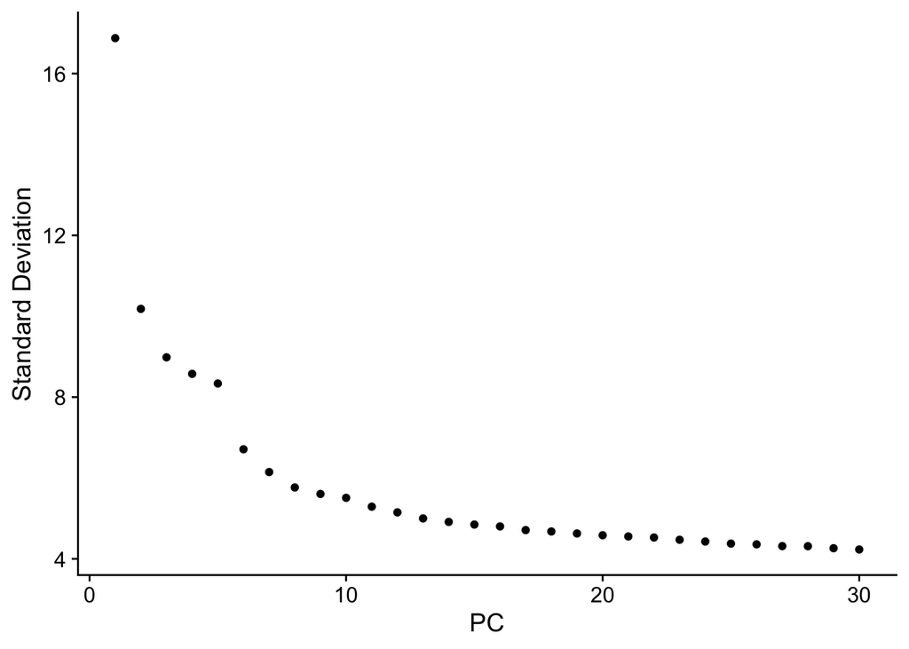

```r
# These are now standard steps in the Seurat workflow for visualization and clustering
seuset <- RunPCA(seuset, verbose = FALSE)
ElbowPlot(object = seuset, ndims = 30)
```

```r
seuset <- RunUMAP(seuset, dims = 1:30, verbose = FALSE)

seuset <- FindNeighbors(seuset, dims = 1:30, verbose = FALSE)
seuset <- FindClusters(seuset, verbose = FALSE,resolution = 1)

seuset_pijuan <- seuset
```

#### UMAP visualisation

Extract the UMAP dimension

```r
umap.df <- as.data.frame(Embeddings(object = seuset, reduction = "umap")) %>%
  tibble::rownames_to_column(var="Cell") %>%
  cbind(seuset[[]])


# Subset based on sorted population
p1 <-
  ggplot(umap.df, aes(x=UMAP_1, y=UMAP_2, colour=condition)) +
  geom_point() +
  gghighlight(use_direct_label = FALSE) +
  theme(legend.position = "right") +
  facet_wrap(~condition) +
  theme_bw() +
  #scale_colour_manual(values=pal.pop2_sub) +
  labs(title="Highlighting the FACS population")

p2 <-
  ggplot(umap.df, aes(x=UMAP_1, y=UMAP_2, colour=seurat_clusters)) +
  geom_point() +
  gghighlight(use_direct_label = FALSE) +
  theme(legend.position = "right") +
  facet_wrap(~seurat_clusters) +
  theme_bw() +
  #scale_colour_manual(values=pal.pop2_sub) +
  labs(title="Highlighting the in silico clusters")

png(file.path(outDir_Pijuan, "E8.25_SmartSeq_UMAP_condition.png"), width=1200, height=900)
p1
dev.off()
```

```r
png(file.path(outDir_Pijuan, "E8.25_SmartSeq_UMAP_cluster.png"), width=1200, height=900)
p2
dev.off()
```

### E8

> To do E8 data if required

### E8.25

```r
set.seed(123)
seu_8.25 <- readRDS(file.path(dataDir, "publicData/obj_E8.25_exp.rds"))
dat_E8.25 <- seu_8.25[[]]

# ------ Select interested population ------ #
# Subset cells from the endothelial lineage
tmp <- filter(dat_E8.25, Anno == "E8.25:Endothelium")  %>%
  filter(pre_celltype %in% c("Endothelium", "Haematoendothelial progenitors"))
table(tmp$pre_celltype)
```

```
##
##                    Endothelium Haematoendothelial progenitors
##                            337                             65
```

```r
# Limit the ell number of the endothelium to 50 and select all Haematoendothelial
tmp <- stratified(tmp, group="pre_celltype",
                  size = c(Endothelium = 50, 'Haematoendothelial progenitors' = 50))
                  #size = c(Endothelium = 50)

# Subset cells from Haematoendothelial progenitors
tmp2 <- filter(dat_E8.25, Anno == "E8.25:Haematoendothelial progenitors")  %>%
  filter(pre_celltype %in% c("Haematoendothelial progenitors"))
table(tmp2$pre_celltype)
```

```
##
## Haematoendothelial progenitors
##                            368
```

```r
# Limit the ell number of the Haematoendothelial to 100
tmp2 <- stratified(tmp2, group="pre_celltype",
                   size = c('Haematoendothelial progenitors' = 100))

# Subset cells from blood progenitor
tmp3 <- filter(dat_E8.25, Anno == "E8.25:Blood progenitors")  %>%
  filter(pre_celltype %in% c("Blood progenitors 1", "Blood progenitors 2"))
table(tmp3$pre_celltype)
```

```
##
## Blood progenitors 1 Blood progenitors 2
##                  33                  72
```

```r
selcells <- unique(c(row.names(tmp), row.names(tmp2), row.names(tmp3)))

seu_8.25_sub  <- seu_8.25[,colnames(seu_8.25) %in% selcells]
table(seu_8.25_sub$pre_celltype)
```

```
##
##            Blood progenitors 1            Blood progenitors 2
##                             33                             72
##                    Endothelium Haematoendothelial progenitors
##                             50                            150
```

### E8.5

```r
set.seed(123)
seu_8.5 <- readRDS(file.path(dataDir, "publicData/obj_E8.5_exp.rds"))
dat_E8.5 <- seu_8.5[[]]

# ------ Select interested population ------ #
# Subset cells from the endothelial lineage
tmp <- filter(dat_E8.5, Anno == "E8.5:Endothelium")  %>%
  filter(pre_celltype %in% c("Endothelium", "Haematoendothelial progenitors"))
table(tmp$pre_celltype)
```

```
##
##                    Endothelium Haematoendothelial progenitors
##                            463                            149
```

```r
# Limit the ell number of the endothelium to 50
tmp <- stratified(tmp, group="pre_celltype",
                  size = c(Endothelium = 50, 'Haematoendothelial progenitors' = 100))

# Subset cells from Haematoendothelial progenitors
tmp2 <- filter(dat_E8.5, Anno == "E8.5:Haematoendothelial progenitors")  %>%
  filter(pre_celltype %in% c("Haematoendothelial progenitors"))
table(tmp2$pre_celltype)
```

```
##
## Haematoendothelial progenitors
##                            236
```

```r
tmp2 <- stratified(tmp2, group="pre_celltype",
                  size = ('Haematoendothelial progenitors' = 100))

# Subset cells from blood progenitor
tmp3 <- filter(dat_E8.5, Anno == "E8.5:Blood progenitors")  %>%
  filter(pre_celltype %in% c("Blood progenitors 1", "Blood progenitors 2"))
table(tmp3$pre_celltype)
```

```
##
## Blood progenitors 1 Blood progenitors 2
##                  35                  78
```

```r
selcells <- c(row.names(tmp), row.names(tmp2), row.names(tmp3))

seu_8.5_sub  <- seu_8.5[,colnames(seu_8.5) %in% selcells]
table(seu_8.5_sub$pre_celltype)
```

```
##
##            Blood progenitors 1            Blood progenitors 2
##                             35                             78
##                    Endothelium Haematoendothelial progenitors
##                             50                            200
```

### Normalize

```r
# -------- E8.25 ----------- #
seuset <- seu_8.25_sub
# Convert ENS ID to symbol
## Remove ENS genes that is present in the gastrilation data that is not present in our data
rD <- rowData((nova.sce)) %>%
  as.data.frame()
ourGenes <- rD %>% pull(ID)
gastGene <- row.names(seuset)
gastGene_sub <- gastGene[gastGene %in% ourGenes]
seuset <- seuset[row.names(seuset) %in% gastGene_sub,]
## Converting gene names
rD_sub <- rD[row.names(seuset),]
identical(rD_sub$ID, row.names(seuset))
```

```
## [1] TRUE
```

```r
new.row.names <- uniquifyFeatureNames(
    rD_sub$ID,
    rD_sub$Symbol
)
# No easy way to rename Seurat objects https://github.com/satijalab/seurat/issues/1049
# So convert it to sce object, then create seurat object
se.tmp <- as.SingleCellExperiment(seuset)
row.names(se.tmp) <- new.row.names
seuset <-
  Seurat::CreateSeuratObject(counts = assay(se.tmp, "counts"),
                     project = "E8.25",
                     meta.data = as.data.frame(colData(se.tmp)),
                     min.cells = 3, min.features = 200)
# Normalize
seuset <- NormalizeData(
  object = seuset,
  normalization.method = "LogNormalize",
  scale.factor = 10000
)
# Feature selections
seuset <-
  FindVariableFeatures(object = seuset, selection.method = "vst", nfeatures = 2500)
# Scaling the data
all.genes <- rownames(x = seuset)
seuset <- ScaleData(object = seuset, features = all.genes)
# Cell cycle
seuset <- CellCycleScoring(seuset, s.features = s.genes, g2m.features = g2m.genes, set.ident = FALSE)
seuset <- RunPCA(seuset, verbose = FALSE)
seuset <- RunUMAP(seuset, dims = 1:30, verbose = FALSE)

seuset <- FindNeighbors(seuset, dims = 1:30, verbose = FALSE)
seuset <- FindClusters(seuset, verbose = FALSE,resolution = 1)

# SAve
seu_8.25_sub <- seuset



# -------- E8.5 ----------- #
seuset <- seu_8.5_sub
# Convert ENS ID to symbol
## Remove ENS genes that is present in the gastrilation data that is not present in our data
rD <- rowData((nova.sce)) %>%
  as.data.frame()
ourGenes <- rD %>% pull(ID)
gastGene <- row.names(seuset)
gastGene_sub <- gastGene[gastGene %in% ourGenes]
seuset <- seuset[row.names(seuset) %in% gastGene_sub,]
## Converting gene names
rD_sub <- rD[row.names(seuset),]
identical(rD_sub$ID, row.names(seuset))
```

```
## [1] TRUE
```

```r
new.row.names <- uniquifyFeatureNames(
    rD_sub$ID,
    rD_sub$Symbol
)
# No easy way to rename Seurat objects https://github.com/satijalab/seurat/issues/1049
# So convert it to sce object, then create seurat object
se.tmp <- as.SingleCellExperiment(seuset)
row.names(se.tmp) <- new.row.names
seuset <-
  Seurat::CreateSeuratObject(counts = assay(se.tmp, "counts"),
                     project = "E8.5",
                     meta.data = as.data.frame(colData(se.tmp)),
                     min.cells = 3, min.features = 200)
# Normalize
seuset <- NormalizeData(
  object = seuset,
  normalization.method = "LogNormalize",
  scale.factor = 10000
)
# Feature selections
seuset <-
  FindVariableFeatures(object = seuset, selection.method = "vst", nfeatures = 2500)
# Scaling the data
all.genes <- rownames(x = seuset)
seuset <- ScaleData(object = seuset, features = all.genes)
# Cell cycle
seuset <- CellCycleScoring(seuset, s.features = s.genes, g2m.features = g2m.genes, set.ident = FALSE)
seuset <- RunPCA(seuset, verbose = FALSE)
seuset <- RunUMAP(seuset, dims = 1:30, verbose = FALSE)

seuset <- FindNeighbors(seuset, dims = 1:30, verbose = FALSE)
seuset <- FindClusters(seuset, verbose = FALSE,resolution = 1)

seu_8.5_sub <- seuset
```

#### UMAP visualisation

Extract the UMAP dimension

```r
umap.df <- as.data.frame(Embeddings(object = seu_8.5_sub, reduction = "umap")) %>%
  tibble::rownames_to_column(var="Cell") %>%
  cbind(seu_8.5_sub[[]])


# Subset based on sorted population
p1 <-
  ggplot(umap.df, aes(x=UMAP_1, y=UMAP_2, colour=pre_celltype)) +
  geom_point() +
  gghighlight(use_direct_label = FALSE) +
  theme(legend.position = "right") +
  facet_wrap(~pre_celltype) +
  theme_bw() +
  #scale_colour_manual(values=pal.pop2_sub) +
  labs(title="Highlighting the cell annotation")

p2 <-
  ggplot(umap.df, aes(x=UMAP_1, y=UMAP_2, colour=seurat_clusters)) +
  geom_point() +
  gghighlight(use_direct_label = FALSE) +
  theme(legend.position = "right") +
  facet_wrap(~seurat_clusters) +
  theme_bw() +
  #scale_colour_manual(values=pal.pop2_sub) +
  labs(title="Highlighting the in silico clusters")

png(file.path(outDir_Pijuan, "E8.5_10x_UMAP_condition.png"), width=1200, height=900)
p1
dev.off()
```

```r
png(file.path(outDir_Pijuan, "E8.5_10x_UMAP_cluster.png"), width=1200, height=900)
p2
dev.off()
```

```r
umap.df <- as.data.frame(Embeddings(object = seu_8.25_sub, reduction = "umap")) %>%
  tibble::rownames_to_column(var="Cell") %>%
  cbind(seu_8.25_sub[[]])


# Subset based on sorted population
p1 <-
  ggplot(umap.df, aes(x=UMAP_1, y=UMAP_2, colour=pre_celltype)) +
  geom_point() +
  gghighlight(use_direct_label = FALSE) +
  theme(legend.position = "right") +
  facet_wrap(~pre_celltype) +
  theme_bw() +
  #scale_colour_manual(values=pal.pop2_sub) +
  labs(title="Highlighting the cell annotation")

p2 <-
  ggplot(umap.df, aes(x=UMAP_1, y=UMAP_2, colour=seurat_clusters)) +
  geom_point() +
  gghighlight(use_direct_label = FALSE) +
  theme(legend.position = "right") +
  facet_wrap(~seurat_clusters) +
  theme_bw() +
  #scale_colour_manual(values=pal.pop2_sub) +
  labs(title="Highlighting the in silico clusters")

png(file.path(outDir_Pijuan, "E8.25_10x_UMAP_condition.png"), width=1200, height=900)
p1
dev.off()
```

```r
png(file.path(outDir_Pijuan, "E8.25_10x_UMAP_cluster.png"), width=1200, height=900)
p2
dev.off()
```

### Mouse atlas data

```r
outDir_atlas <- file.path(outDir_cur, "Cao_2019")
dir.create(outDir_atlas)
```

The original publication of this paper is from https://pubmed.ncbi.nlm.nih.gov/30787437/. However we downloaded this data from http://tome.gs.washington.edu/

```r
seu_9.5 <- readRDS(file.path(dataDir, "publicData/obj_E9.5_exp.rds"))
dat_E9.5 <- seu_9.5[[]]

# ------ Select interested population ------ #
# Subset to cells from the endothelial lineage
tmp <- filter(dat_E9.5, Anno == "E9.5:Endothelium")  %>%
  filter(sub_trajectory %in% c("Arterial endothelial trajectory", "Venous and capillary endothelial trajectory"))
table(tmp$sub_trajectory)
```

```
##
##             Arterial endothelial trajectory
##                                         478
## Venous and capillary endothelial trajectory
##                                        2258
```

```r
tmp <- stratified(tmp, group="sub_trajectory",
                  size = c('Arterial endothelial trajectory' = 50, 'Venous and capillary endothelial trajectory' = 50))


#Cells from blood progenitor
tmp2 <- filter(dat_E9.5, Anno == "E9.5:Blood progenitors") %>% # Only 138 cells so we dont do further filtering
  filter(!sub_trajectory %in%  c("Definitive erythroid trajectory", "Venous and capillary endothelial trajectory")) %>% # Only 10 cells in here, so we remove it
  filter(!pre_celltype %in%  c("Definitive erythrocyte lineage")) # Only 10 cells in here, so we remove it

table(tmp2$sub_trajectory)
```

```
##
##    Megakaryocyte trajectory White blood cell trajectory
##                          55                          72
```

```r
tmp3 <- filter(dat_E9.5, main_trajectory == "Haematopoiesis trajectory") %>% # Only 138 cells so we dont do further filtering
  filter(pre_celltype %in%  c("Definitive erythrocyte lineage", "Primitive erythroid lineage")) %>%
  filter(!Anno %in%  c("E9.5:Stromal cells"))

tmp3 <- stratified(tmp3, group="pre_celltype",
                  size = c('Primitive erythroid lineage' = 50, 'Definitive erythrocyte lineage' = 20))

selcells <- unique(c(row.names(tmp), row.names(tmp2), row.names(tmp3)))

seu_9.5_sub  <- seu_9.5[,colnames(seu_9.5) %in% selcells]
table(seu_9.5_sub$pre_celltype)
```

```
##
## Definitive erythrocyte lineage              Endothelial cells
##                             20                            100
##                 Megakaryocytes    Primitive erythroid lineage
##                             56                             50
##              White blood cells
##                             71
```

#### Normalise

```r
# -------- E9.5 ----------- #
seuset <- seu_9.5_sub
# Convert ENS ID to symbol
## Remove ENS genes that is present in the gastrilation data that is not present in our data
rD <- rowData((nova.sce)) %>%
  as.data.frame()
ourGenes <- rD %>% pull(ID)
gastGene <- row.names(seuset)
gastGene_sub <- gastGene[gastGene %in% ourGenes]
seuset <- seuset[row.names(seuset) %in% gastGene_sub,]
## Converting gene names
rD_sub <- rD[row.names(seuset),]
identical(rD_sub$ID, row.names(seuset))
```

```
## [1] TRUE
```

```r
new.row.names <- uniquifyFeatureNames(
    rD_sub$ID,
    rD_sub$Symbol
)
# No easy way to rename Seurat objects https://github.com/satijalab/seurat/issues/1049
# So convert it to sce object, then create seurat object
se.tmp <-
  SingleCellExperiment(
    assays = list(counts = GetAssayData(object = seuset, slot = "counts")),
    colData = seuset[[]],
    rowData = rD_sub)
row.names(se.tmp) <- new.row.names
seuset <-
  Seurat::CreateSeuratObject(counts = assay(se.tmp, "counts"),
                     project = "E9.5",
                     meta.data = as.data.frame(colData(se.tmp)),
                     min.cells = 3, min.features = 200)
# Normalize
seuset <- NormalizeData(
  object = seuset,
  normalization.method = "LogNormalize",
  scale.factor = 10000
)
# Feature selections
seuset <-
  FindVariableFeatures(object = seuset, selection.method = "vst", nfeatures = 2500)
# Scaling the data
all.genes <- rownames(x = seuset)
seuset <- ScaleData(object = seuset, features = all.genes)
# Cell cycle
seuset <- CellCycleScoring(seuset, s.features = s.genes, g2m.features = g2m.genes, set.ident = FALSE)
seuset <- RunPCA(seuset, verbose = FALSE)
seuset <- RunUMAP(seuset, dims = 1:30, verbose = FALSE)

seuset <- FindNeighbors(seuset, dims = 1:30, verbose = FALSE)
seuset <- FindClusters(seuset, verbose = FALSE,resolution = 1)

seu_9.5_sub <- seuset
```

#### UMAP visualisation

Extract the UMAP dimension

```r
umap.df <- as.data.frame(Embeddings(object = seu_9.5_sub, reduction = "umap")) %>%
  tibble::rownames_to_column(var="Cell") %>%
  cbind(seu_9.5_sub[[]])


# Subset based on sorted population
p1 <-
  ggplot(umap.df, aes(x=UMAP_1, y=UMAP_2, colour=pre_celltype)) +
  geom_point() +
  gghighlight(use_direct_label = FALSE) +
  theme(legend.position = "right") +
  facet_wrap(~pre_celltype) +
  theme_bw() +
  #scale_colour_manual(values=pal.pop2_sub) +
  labs(title="Highlighting the cell annotation")

p2 <-
  ggplot(umap.df, aes(x=UMAP_1, y=UMAP_2, colour=seurat_clusters)) +
  geom_point() +
  gghighlight(use_direct_label = FALSE) +
  theme(legend.position = "right") +
  facet_wrap(~seurat_clusters) +
  theme_bw() +
  #scale_colour_manual(values=pal.pop2_sub) +
  labs(title="Highlighting the in silico clusters")

png(file.path(outDir_atlas, "E9.5_UMAP_condition.png"), width=900, height=550)
p1
dev.off()
```

```r
png(file.path(outDir_atlas, "E9.5_UMAP_cluster.png"), width=900, height=450)
p2
dev.off()
```

## Zhou 2016

The original publication of this paper is from https://www.nature.com/articles/nature17997. However we downloaded this data from SRA

```r
outDir_Zhou <- file.path(outDir_cur, "Zhou_2016")
dir.create(outDir_Zhou)
```

There was no processed data provided, so we download the data from GEO

```bash
# 1) Donaload the list of SRA files
# 2) Use the sratoolkit module in cluster to download the SRA files
#  A table of files we want to download is in the data folder
prefetch --option-file SraAccList.txt

# Once data is downloaded by prefetch, we need to process using fasstq-dump convert SRA file to fasta file
fastq-dump --split-e  SRR1922583.sra

# Then we map the data with STAR solo, as we have done with the Next-seq and Smart-Seq2 data
# To map with star solo, we need to supply the manifest file ls -1 $PWD/* > ../tmp.list.txt
```

Generate the single cell object

```r
zhou.sce <- DropletUtils::read10xCounts(file.path(dataDir, "publicData/Zhou_STARsolo/filtered"))
se <- zhou.sce
```

To annotate the genes further, we import the GTF file

```r
simple_gtf <- read.delim(file.path(outDir, "out_data/simple_gtf.txt"))

# Combine GTF with sc object
simple_gtf_sub <- simple_gtf %>%
  select(gene_id, gene_type, seqnames)
rD <- rowData(se) %>%
  as.data.frame() %>%
  left_join(simple_gtf_sub, by = c("ID" = "gene_id"))
```

Add cell metaData

```r
# Read the file accompanying the SRA file
mData_SRA <- read.csv(file.path(dataDir, "publicData/GEO_dowload/Zhou_2016/SraRunTable_Zhou2016.csv"))
# Read the manifest file used as input to STAR solo
mData_starSolo <- read.delim(file.path(dataDir, "publicData/GEO_dowload/Zhou_2016/manifest_Zhou.txt"),header=FALSE)

# We need to link the SRA name with the population identifier (eg T1 pre-HSC, T2 pre-HSC) with the name of the cells as named by STARsolo during mapping
mData_1<- mData_SRA %>%
  dplyr::select(Run, cell_type)
mData_2 <- mData_starSolo %>%
  mutate(Run = gsub("_1.fastq", "", V1),
         Run = gsub(".*fastq/", "", Run)) %>%
  dplyr::rename(Barcode = V3) %>%
  dplyr::select(Run, Barcode)
mData_comb <- left_join(mData_1, mData_2)
# Combine with cell annotation
cD <- colData(se) %>%
  as.data.frame() %>%
  left_join(mData_comb, by = c("Barcode" = "Barcode")) %>%
  dplyr::select(-Sample) %>%
  dplyr::rename(condition = cell_type)
```

Rename the populations in the Zhou data

```r
table(cD$condition)
```

```
##
##                                      E12 HSCs
##                                            21
##                                      E14 HSCs
##                                            32
##                             endothelial cells
##                                            17
##                     Haematopoietic stem cells
##                                            46
## T1 CD201-: CD31+CD45-CD41low c-Kit+CD201low/-
##                                            42
##                                   T2 pre-HSCs
##                                            44
##                                Type1 pre-HSCs
##                                            28
##                                Type2 pre-HSCs
##                                            32
```

New names

```r
NewName <- cD$condition
NewName <- dplyr::case_when(
  NewName == 'endothelial cells' ~ "AGM_E11.0_Endo",
  NewName == 'T1 CD201-: CD31+CD45-CD41low c-Kit+CD201low/-' ~ "AGM_E11.0_T1_preHSC_CD201neg",
  NewName == 'Type1 pre-HSCs' ~ "AGM_E11.0_T1_preHSC_CD201hig",

  NewName == 'T2 pre-HSCs' ~ "AGM_E11.0_T2_preHSC_CD201hig",
  NewName == 'Type2 pre-HSCs' ~ "AGM_E11.0_T2_preHSC",

  NewName == 'E12 HSCs' ~ "FL_E12.0_HSC",
  NewName == 'E14 HSCs' ~ "FL_E14.0_HSC",
  NewName == 'Haematopoietic stem cells' ~ "BM_Adult_HSC",

)
NewName <- factor(NewName, levels=Zhou_lvl)

cD$condition <- NewName
```

Add new colData and rowData to se object

```r
colData(se) <- DataFrame(cD)
rowData(se) <- DataFrame(rD)
```

Remove the un-interested population. From the Zhou study they have the following populations

```r
# table(cD$condition)
```

Convert the population (condition) as factors

```r
#se$condition <- factor(se$condition, levels=nova_popFac)
```

We are interested in the following populations

```r
#popInterest <- c("endothelial cells", "Type1 pre-HSCs", "Type2 pre-HSCs", "E12 HSCs", "E14 HSCs")
#se <- se[,se$condition %in% popInterest]
```

### Filtering low-quality cells

Our first aim is to remove low-quality cells. For all of the run, we apply a threshold to filter the cells. We will use the follwoing

- Number of genes detected
- Percentage of Mitochondira reads
- Percentage of Hemoglobin (Hbb) genes

Find the QC of specific genes

```r
# Specific the location
MT_gene <- rD$seqnames == "chrM"
Hbbs <- rD[grepl("Hb[a-b]", rD$Symbol),] %>% pull(Symbol)
Hbbs <- c(Hbbs, "Gypa")
#Hbbs <- c("Hba-x", "Hbb-bh1", "Hbb-y", "Hba-a1")

# Get the Ens ID
Hb_ens <- rD %>%
  dplyr::filter(Symbol %in% Hbbs)
Hbb_gene <- rowData(se)$ID %in% Hb_ens$ID
```

We examine the distibution of the data in all the run

```r
df_cData <-
  perCellQCMetrics(se,
                   subsets=list(Mito=MT_gene,
                                Hbb=Hbb_gene)) %>%
  cbind(as.data.frame(colData(se))) %>%
  as.data.frame() %>%
  dplyr::mutate(Cell = colnames(se))


# To plot select a subset of columns
df_cData_sub <- as.data.frame(df_cData) %>%
  #tibble::rownames_to_column(var = "Cell") %>%
  dplyr::select(Barcode, sum, detected, subsets_Mito_percent, subsets_Hbb_percent, condition)

m <- melt(df_cData_sub)
```

Plot the distribution

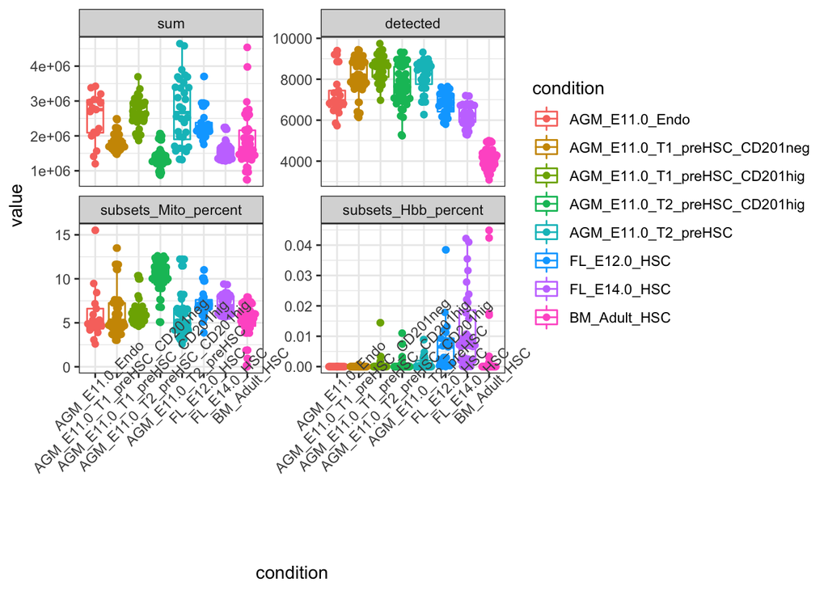

```r
ggplot(m, aes(x=condition, y=value, colour=condition)) +
  geom_boxplot(aes(),fill=NA) +
  geom_quasirandom(dodge.width=0.75) +
  theme_bw()  +
  facet_wrap(~variable, scales = "free_y") +
  theme(axis.text.x = element_text(angle = 45)) +
  NULL
```

Lets apply a cut-off

```r
df_cData_fil <- df_cData_sub %>%
  dplyr::filter(
    detected > 2000,
    subsets_Mito_percent < 15,
    subsets_Hbb_percent < 10)
```

Subset the sc object

```r
se <- se[,se$Barcode %in% df_cData_fil$Barcode]
```

### Filtering lowly-expressed genes

> To do, there is no filtering of lowly-expresed genes in Seurat?

#### Convert to gene symbol

To enable a user-friendly analysis, it is convenient to exchange the ENSEMBL IDs with the name of the genes.

For duplicated gene names, we merge them with the ENSEMBL IDs to avoid confusion.

```r
new.row.names <- uniquifyFeatureNames(
    rowData(se)$ID,
    rowData(se)$Symbol
)

rownames(se) <- new.row.names
head(rownames(se), 5)
```

```
## [1] "Xkr4"    "Gm1992"  "Gm19938" "Gm37381" "Rp1"
```

```r
se_Zhou <- se
```

### Quick seurat

```r
colnames(se) <- se$Barcode
seu <-
  Seurat::CreateSeuratObject(counts = assay(se, "counts"),
                     project = "Zhou",
                     meta.data = as.data.frame(colData(se)),
                     min.cells = 3, min.features = 200)
# Colour scheme
#pal.pop2_sub <- df_pal_pop2 %>%
#  dplyr::filter(Population %in% se2$condition) %>% pull(Col)


seuset <- NormalizeData(
  object = seu,
  normalization.method = "LogNormalize",
  scale.factor = 10000
)
# Feature selections
seuset <-
  FindVariableFeatures(object = seuset, selection.method = "vst", nfeatures = 2500)
# Scaling the data
all.genes <- rownames(x = seuset)
seuset <- ScaleData(object = seuset, features = all.genes)
seuset <- CellCycleScoring(seuset, s.features = s.genes, g2m.features = g2m.genes, set.ident = FALSE)
```

```r
# These are now standard steps in the Seurat workflow for visualization and clustering
seuset <- RunPCA(seuset, verbose = FALSE)
#ElbowPlot(object = seuset, ndims = 30)
seuset <- RunUMAP(seuset, dims = 1:30, verbose = FALSE)

seuset <- FindNeighbors(seuset, dims = 1:30, verbose = FALSE)
seuset <- FindClusters(seuset, verbose = FALSE,resolution = 1)

seuset_zhou <- seuset
```

#### UMAP visualisation

Extract the UMAP dimension

```r
umap.df <- as.data.frame(Embeddings(object = seuset, reduction = "umap")) %>%
  tibble::rownames_to_column(var="Cell") %>%
  cbind(seuset[[]])


# Subset based on sorted population
p1 <-
  ggplot(umap.df, aes(x=UMAP_1, y=UMAP_2, colour=condition)) +
  geom_point() +
  gghighlight(use_direct_label = FALSE) +
  theme(legend.position = "right") +
  facet_wrap(~condition) +
  theme_bw() +
  #scale_colour_manual(values=pal.pop2_sub) +
  labs(title="Highlighting the FACS population")

p2 <-
  ggplot(umap.df, aes(x=UMAP_1, y=UMAP_2, colour=seurat_clusters)) +
  geom_point() +
  gghighlight(use_direct_label = FALSE) +
  theme(legend.position = "right") +
  facet_wrap(~seurat_clusters) +
  theme_bw() +
  #scale_colour_manual(values=pal.pop2_sub) +
  labs(title="Highlighting the in silico clusters")

png(file.path(outDir_Zhou, "Zhou_UMAP_condition.png"), width=1200, height=900)
p1
dev.off()
```

```r
png(file.path(outDir_Zhou, "Zhou_UMAP_cluster.png"), width=1200, height=900)
p2
dev.off()
```

```r
su.markers <-
  FindAllMarkers(seuset, only.pos = TRUE, min.pct = 0.25, logfc.threshold = 0.25)
write.csv(su.markers, file.path(outDir_Zhou, "MarkerGenes.csv"))
```

#### Filtering clusters

Cluster 5 showed no expression of CD27 and very high expression of Macrophage (Fcr gene family) expression. So we remove all cluster 5

```r
seuset <- seuset[,!seuset$seurat_clusters == "5"]
```

Re-run clustering and variable genes

```r
# Feature selections
seuset <-
  FindVariableFeatures(object = seuset, selection.method = "vst", nfeatures = 2500)
# Scaling the data
all.genes <- rownames(x = seuset)
seuset <- ScaleData(object = seuset, features = all.genes)
```

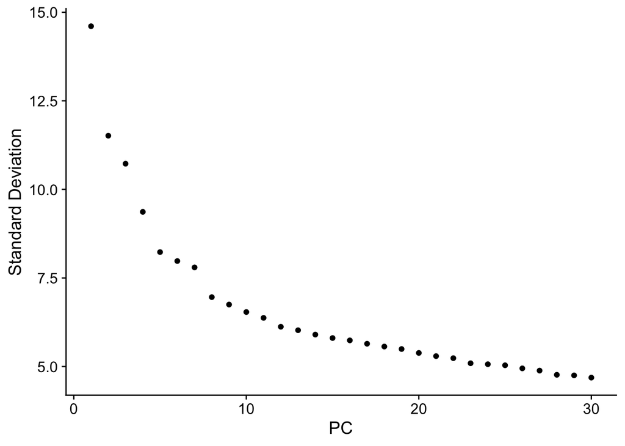

```r
# These are now standard steps in the Seurat workflow for visualization and clustering
seuset <- RunPCA(seuset, verbose = FALSE)
ElbowPlot(object = seuset, ndims = 30)
```

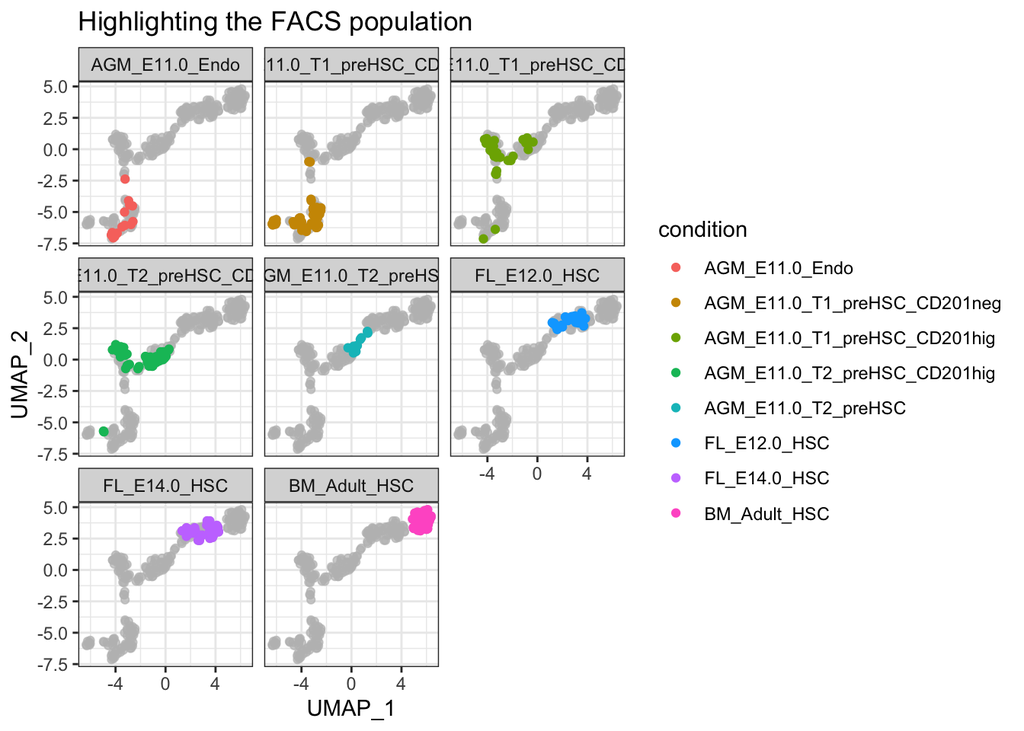

```r
seuset <- RunUMAP(seuset, dims = 1:30, verbose = FALSE)

seuset <- FindNeighbors(seuset, dims = 1:30, verbose = FALSE)
seuset <- FindClusters(seuset, verbose = FALSE,resolution = 1)

seuset_zhou<- seuset


umap.df <- as.data.frame(Embeddings(object = seuset, reduction = "umap")) %>%
  tibble::rownames_to_column(var="Cell") %>%
  cbind(seuset[[]])


# Subset based on sorted population
p1 <-
  ggplot(umap.df, aes(x=UMAP_1, y=UMAP_2, colour=condition)) +
  geom_point() +
  gghighlight(use_direct_label = FALSE) +
  theme(legend.position = "right") +
  facet_wrap(~condition) +
  theme_bw() +
  #scale_colour_manual(values=pal.pop2_sub) +
  labs(title="Highlighting the FACS population")

p1
```

## Hou 2020

```r
outDir_Hou <- file.path(outDir_cur, "Hou_2020")
dir.create(outDir_Hou)
```

The original publication of this paper is from https://www.nature.com/articles/s41422-020-0300-2. We downloaded this data from [GEO](https://www.ncbi.nlm.nih.gov/geo/query/acc.cgi?acc=GSE139389) where the raw count is provided. So we process the provided file

```r
dat1 <- read.delim(file.path(dataDir, "publicData/GEO_dowload/Hou_2020/GSM4140378_E11.0_AGM_T1_EC81.txt"))
dat2 <- read.delim(file.path(dataDir, "publicData/GEO_dowload/Hou_2020/GSM4140379_E11.0_AGM_T1_EC82.txt"))
dat3 <- read.delim(file.path(dataDir, "publicData/GEO_dowload/Hou_2020/GSM4140374_E10.0_AGM_PK44_EC73.txt"))
dat4 <- read.delim(file.path(dataDir, "publicData/GEO_dowload/Hou_2020/GSM4140375_E10.0_AGM_PK44_EC74.txt"))

dat <- cbind(dat1,dat2,dat3,dat4)

c.anno <-
  data.frame(
    Cell = c(colnames(dat1), colnames(dat2), colnames(dat3), colnames(dat4)),
    condition = c(rep("AGM_E11.0_T1_preHSC", ncol(dat1)),
             rep("AGM_E11.0_T1_preHSC", ncol(dat2)),
             rep("AGM_E11.0_PK44", ncol(dat3)),
             rep("AGM_E11.0_PK44", ncol(dat4)))
  )


hou.sce <-
  SingleCellExperiment(
  assays = list(counts = dat),
  colData = c.anno)


# Remove genes symbol that is present in Nancy data that is not present in our data
ourGenes <- rowData(nova.sce)$Symbol
houGenes <- row.names(hou.sce)

houGenes_sub <- houGenes[houGenes %in% ourGenes]


hou.sce <- hou.sce[row.names(hou.sce) %in% houGenes_sub,]

se <- hou.sce
```

### Filtering low-quality cells

Our first aim is to remove low-quality cells. For all of the run, we apply a threshold to filter the cells. We will use the follwoing

- Number of genes detected
- Percentage of Hemoglobin (Hbb) genes

Find the QC of specific genes

```r
Hbb_gene <- row.names(se) %in% Hb_ens$Symbol
```

We examine the distibution of the data in all the run

```r
df_cData <-
  perCellQCMetrics(se,
                   subsets=list(#Mito=MT_gene,
                                Hbb=Hbb_gene)) %>%
  cbind(as.data.frame(colData(se))) %>%
  as.data.frame() %>%
  dplyr::mutate(Cell = colnames(se))


# To plot select a subset of columns
df_cData_sub <- as.data.frame(df_cData) %>%
  #tibble::rownames_to_column(var = "Cell") %>%
  dplyr::select(Cell, sum, detected, subsets_Hbb_percent, condition)

m <- melt(df_cData_sub)
```

Plot the distribution

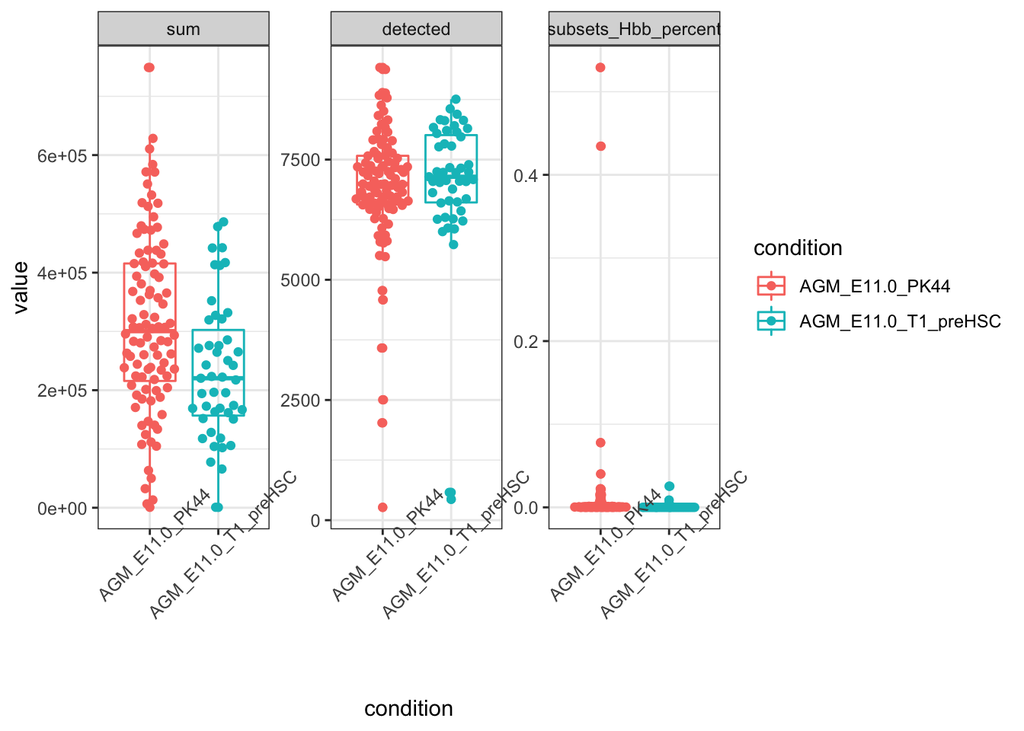

```r
ggplot(m, aes(x=condition, y=value, colour=condition)) +
  geom_boxplot(aes(),fill=NA) +
  geom_quasirandom(dodge.width=0.75) +
  theme_bw()  +
  facet_wrap(~variable, scales = "free_y") +
  theme(axis.text.x = element_text(angle = 45)) +
  NULL
```

Lets apply a cut-off

```r
df_cData_fil <- df_cData_sub %>%
  dplyr::filter(
    detected > 2000,
    #subsets_Mito_percent < 15,
    subsets_Hbb_percent < 10)
```

Subset the sc object

```r
se <- se[,se$Cell %in% df_cData_fil$Cell]
```

### Filtering lowly-expressed genes

> To do, there is no filtering of lowly-expresed genes in Seurat?

#### Convert to gene symbol

To enable a user-friendly analysis, it is convenient to exchange the ENSEMBL IDs with the name of the genes.

For duplicated gene names, we merge them with the ENSEMBL IDs to avoid confusion.

We dont need to do this as this data already has the gene symbol annotated

### Quick seurat

```r
seu <-
  Seurat::CreateSeuratObject(counts = assay(se, "counts"),
                     project = "Hou",
                     meta.data = as.data.frame(colData(se)),
                     min.cells = 3, min.features = 200)

seuset <- NormalizeData(
  object = seu,
  normalization.method = "LogNormalize",
  scale.factor = 10000
)
# Feature selections
seuset <-
  FindVariableFeatures(object = seuset, selection.method = "vst", nfeatures = 2500)
# Scaling the data
all.genes <- rownames(x = seuset)
seuset <- ScaleData(object = seuset, features = all.genes)
seuset <- CellCycleScoring(seuset, s.features = s.genes, g2m.features = g2m.genes, set.ident = FALSE)
```

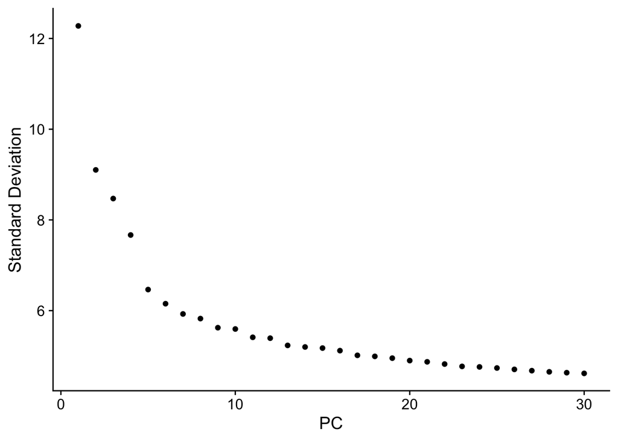

```r
# These are now standard steps in the Seurat workflow for visualization and clustering
seuset <- RunPCA(seuset, verbose = FALSE)
ElbowPlot(object = seuset, ndims = 30)
```

```r
seuset <- RunUMAP(seuset, dims = 1:30, verbose = FALSE)

seuset <- FindNeighbors(seuset, dims = 1:30, verbose = FALSE)
seuset <- FindClusters(seuset, verbose = FALSE,resolution = 1)

seuset_hou <- seuset
```

#### UMAP visualisation

Extract the UMAP dimension

```r
umap.df <- as.data.frame(Embeddings(object = seuset, reduction = "umap")) %>%
  #tibble::rownames_to_column(var="Cell") %>%
  cbind(seuset[[]])


# Subset based on sorted population
p1 <-
  ggplot(umap.df, aes(x=UMAP_1, y=UMAP_2, colour=condition)) +
  geom_point() +
  gghighlight(use_direct_label = FALSE) +
  theme(legend.position = "right") +
  facet_wrap(~condition) +
  theme_bw() +
  #scale_colour_manual(values=pal.pop2_sub) +
  labs(title="Highlighting the FACS population")

p2 <-
  ggplot(umap.df, aes(x=UMAP_1, y=UMAP_2, colour=seurat_clusters)) +
  geom_point() +
  gghighlight(use_direct_label = FALSE) +
  theme(legend.position = "right") +
  facet_wrap(~seurat_clusters) +
  theme_bw() +
  #scale_colour_manual(values=pal.pop2_sub) +
  labs(title="Highlighting the in silico clusters")

png(file.path(outDir_Hou, "UMAP_condition.png"), width=1200, height=900)
p1
dev.off()
```

```r
png(file.path(outDir_Hou, "UMAP_cluster.png"), width=1200, height=900)
p2
dev.off()
```

## Vink 2020

The original publication of this paper is from https://pubmed.ncbi.nlm.nih.gov/32402290/. However we downloaded this data from SRA

```r
outDir_Vink <- file.path(outDir_cur, "Vink_2020")
dir.create(outDir_Vink)
```

There was no processed data provided, so we download the data from GEO

```bash
# 1) Donaload the list of SRA files
# 2) Use the sratoolkit module in cluster to download the SRA files
#  A table of files we want to download is in the data folder
prefetch --option-file SraAccList.txt

# Once data is downloaded by prefetch, we need to process using fasstq-dump convert SRA file to fasta file
fastq-dump --split-e  SRR1922583.sra

# Then we map the data with STAR solo, as we have done with the Next-seq and Smart-Seq2 data
# To map with star solo, we need to supply the manifest file ls -1 $PWD/* > ../tmp.list.txt
```

Generate the single cell object

```r
vink.sce <- DropletUtils::read10xCounts(file.path(dataDir, "publicData/Vink_STARsolo/filtered"))
se <- vink.sce
```

To annotate the genes further, we import the GTF file

```r
simple_gtf <- read.delim(file.path(outDir, "out_data/simple_gtf.txt"))

# Combine GTF with sc object
simple_gtf_sub <- simple_gtf %>%
  select(gene_id, gene_type, seqnames)
rD <- rowData(se) %>%
  as.data.frame() %>%
  left_join(simple_gtf_sub, by = c("ID" = "gene_id"))
```

Add cell metaData

```r
# Read the file accompanying the SRA file
mData_SRA <- read.csv(file.path(dataDir, "publicData/GEO_dowload/Vink_2020/SraRunTable_Vink_2020.csv"))
# Read the manifest file used as input to STAR solo
mData_starSolo <- read.delim(file.path(dataDir, "publicData/GEO_dowload/Vink_2020/manifest_Vink.txt"),header=FALSE)

# We need to link the SRA name with the population identifier (eg T1 pre-HSC, T2 pre-HSC) with the name of the cells as named by STARsolo during mapping
mData_1<- mData_SRA %>%
  dplyr::select(Run, condition, Days)
mData_2 <- mData_starSolo %>%
  mutate(Run = gsub(".fastq", "", V1),
         Run = gsub(".*Vink_2020/", "", Run)) %>%
  dplyr::rename(Barcode = V3) %>%
  dplyr::select(Run, Barcode)
mData_comb <- left_join(mData_1, mData_2)
# Combine with cell annotation
cD <- colData(se) %>%
  as.data.frame() %>%
  left_join(mData_comb, by = c("Barcode" = "Barcode")) %>%
  dplyr::select(-Sample) #%>%
  #dplyr::rename(condition = cell_type)
```

Not of the populations in the Vink data. G2V: Gata2IRESVenus reporter

- G2VInt - Intermediate
- G2VLo - Low
- CD27+ - CD27 pos cells

```r
table(cD$condition)
```

```
##
##  CD27+ G2VInt  G2VLo
##    113    495    439
```

Add new colData and rowData to se object

```r
colData(se) <- DataFrame(cD)
rowData(se) <- DataFrame(rD)
```

### Filtering low-quality cells

Our first aim is to remove low-quality cells. For all of the run, we apply a threshold to filter the cells. We will use the follwoing

- Number of genes detected
- Percentage of Mitochondira reads
- Percentage of Hemoglobin (Hbb) genes

Find the QC of specific genes

```r
# Specific the location
MT_gene <- rD$seqnames == "chrM"
Hbbs <- rD[grepl("Hb[a-b]", rD$Symbol),] %>% pull(Symbol)
Hbbs <- c(Hbbs, "Gypa")
#Hbbs <- c("Hba-x", "Hbb-bh1", "Hbb-y", "Hba-a1")

# Get the Ens ID
Hb_ens <- rD %>%
  dplyr::filter(Symbol %in% Hbbs)
Hbb_gene <- rowData(se)$ID %in% Hb_ens$ID
```

We examine the distibution of the data in all the run

```r
df_cData <-
  perCellQCMetrics(se,
                   subsets=list(Mito=MT_gene,
                                Hbb=Hbb_gene)) %>%
  cbind(as.data.frame(colData(se))) %>%
  as.data.frame() %>%
  dplyr::mutate(Cell = colnames(se))


# To plot select a subset of columns
df_cData_sub <- as.data.frame(df_cData) %>%
  #tibble::rownames_to_column(var = "Cell") %>%
  dplyr::select(Barcode, sum, detected, subsets_Mito_percent, subsets_Hbb_percent, condition)

m <- melt(df_cData_sub)
```

Plot the distribution

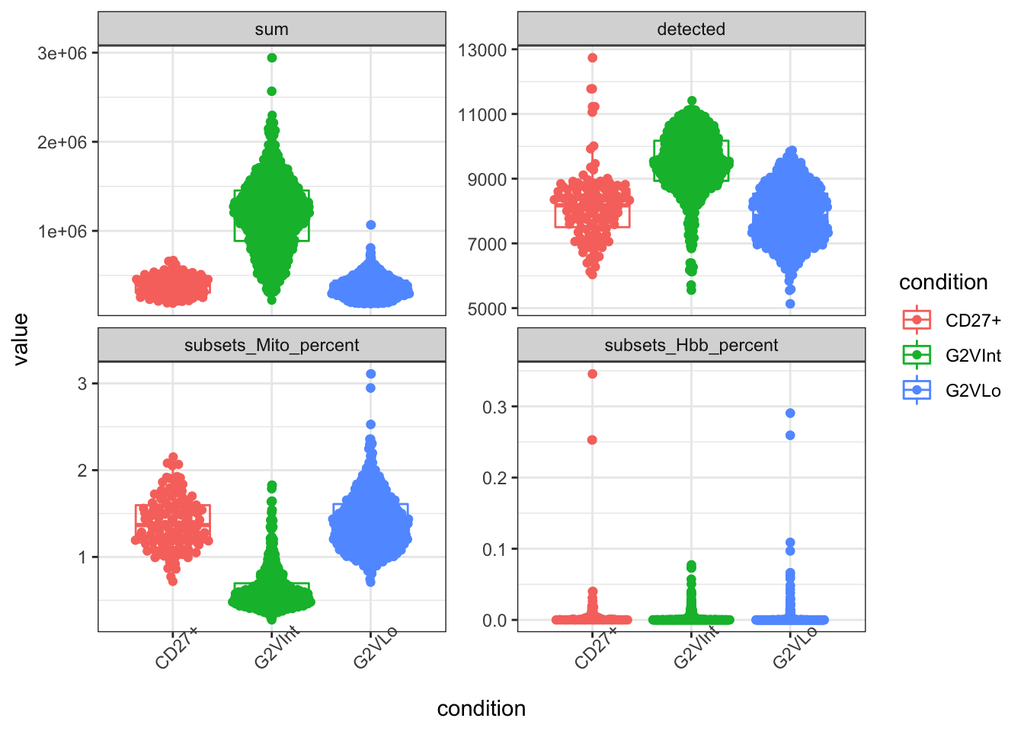

```r
ggplot(m, aes(x=condition, y=value, colour=condition)) +
  geom_boxplot(aes(),fill=NA) +
  geom_quasirandom(dodge.width=0.75) +
  theme_bw()  +
  facet_wrap(~variable, scales = "free_y") +
  theme(axis.text.x = element_text(angle = 45)) +
  NULL
```

Lets apply a cut-off

```r
df_cData_fil <- df_cData_sub %>%
  dplyr::filter(
    detected > 2000,
    subsets_Mito_percent < 15,
    subsets_Hbb_percent < 10)
```

Subset the sc object

```r
se <- se[,se$Barcode %in% df_cData_fil$Barcode]
```

### Filtering lowly-expressed genes

> To do, there is no filtering of lowly-expresed genes in Seurat?

#### Convert to gene symbol

To enable a user-friendly analysis, it is convenient to exchange the ENSEMBL IDs with the name of the genes.

For duplicated gene names, we merge them with the ENSEMBL IDs to avoid confusion.

```r
new.row.names <- uniquifyFeatureNames(
    rowData(se)$ID,
    rowData(se)$Symbol
)

rownames(se) <- new.row.names
head(rownames(se), 5)
```

```
## [1] "Xkr4"    "Gm1992"  "Gm19938" "Gm37381" "Rp1"
```

```r
se_Vink <- se
```

### Quick seurat

```r
colnames(se) <- se$Barcode
seu <-
  Seurat::CreateSeuratObject(counts = assay(se, "counts"),
                     project = "Vink",
                     meta.data = as.data.frame(colData(se)),
                     min.cells = 3, min.features = 200)
# Colour scheme
#pal.pop2_sub <- df_pal_pop2 %>%
#  dplyr::filter(Population %in% se2$condition) %>% pull(Col)


seuset <- NormalizeData(
  object = seu,
  normalization.method = "LogNormalize",
  scale.factor = 10000
)
# Feature selections
seuset <-
  FindVariableFeatures(object = seuset, selection.method = "vst", nfeatures = 2500)
# Scaling the data
all.genes <- rownames(x = seuset)
seuset <- ScaleData(object = seuset, features = all.genes)
seuset <- CellCycleScoring(seuset, s.features = s.genes, g2m.features = g2m.genes, set.ident = FALSE)
```

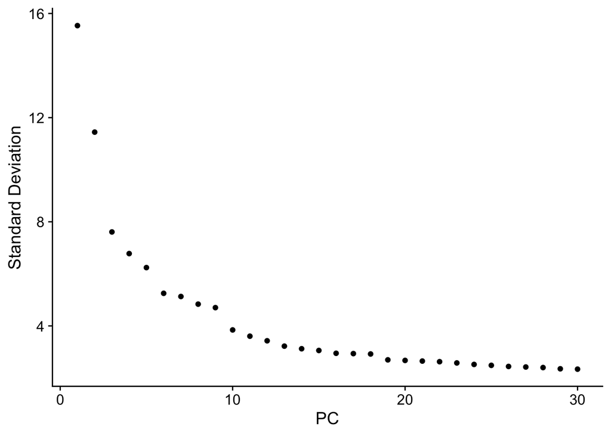

```r
# These are now standard steps in the Seurat workflow for visualization and clustering
seuset <- RunPCA(seuset, verbose = FALSE)
ElbowPlot(object = seuset, ndims = 30)
```

```r
seuset <- RunUMAP(seuset, dims = 1:30, verbose = FALSE)

seuset <- FindNeighbors(seuset, dims = 1:30, verbose = FALSE)
seuset <- FindClusters(seuset, verbose = FALSE)

seuset_vink <- seuset
```

#### UMAP visualisation

Extract the UMAP dimension

```r
umap.df <- as.data.frame(Embeddings(object = seuset, reduction = "umap")) %>%
  tibble::rownames_to_column(var="Cell") %>%
  cbind(seuset[[]])

umap.df_full <- umap.df

# Subset based on sorted population
p1 <-
  ggplot(umap.df, aes(x=UMAP_1, y=UMAP_2, colour=condition)) +
  geom_point() +
  gghighlight(use_direct_label = FALSE) +
  theme(legend.position = "right") +
  facet_wrap(~condition) +
  theme_bw() +
  #scale_colour_manual(values=pal.pop2_sub) +
  labs(title="Highlighting the FACS population")

p1.1 <-
  ggplot(umap.df, aes(x=UMAP_1, y=UMAP_2, colour=Days)) +
  geom_point() +
  gghighlight(use_direct_label = FALSE) +
  theme(legend.position = "right") +
  facet_wrap(~condition) +
  theme_bw() +
  #scale_colour_manual(values=pal.pop2_sub) +
  labs(title="Highlighting the FACS population")

p1.2 <-
  ggplot(umap.df, aes(x=UMAP_1, y=UMAP_2, colour=Phase)) +
  geom_point() +
  gghighlight(use_direct_label = FALSE) +
  theme(legend.position = "right") +
  facet_wrap(~condition) +
  theme_bw() +
  #scale_colour_manual(values=pal.pop2_sub) +
  labs(title="Highlighting the FACS population")

p2 <-
  ggplot(umap.df, aes(x=UMAP_1, y=UMAP_2, colour=seurat_clusters)) +
  geom_point() +
  gghighlight(use_direct_label = FALSE) +
  theme(legend.position = "right") +
  facet_wrap(~seurat_clusters) +
  theme_bw() +
  #scale_colour_manual(values=pal.pop2_sub) +
  labs(title="Highlighting the in silico clusters")

png(file.path(outDir_Vink, "UMAP_condition.png"), width=900, height=450)
p1
dev.off()
```

```r
png(file.path(outDir_Vink, "UMAP_conditionDays.png"), width=900, height=450)
p1.1
dev.off()
```

```r
png(file.path(outDir_Vink, "UMAP_conditionCC.png"), width=900, height=450)
p1.2
dev.off()
```

```r
png(file.path(outDir_Vink, "UMAP_cluster.png"), width=1200, height=900)
p2
dev.off()
```

#### Filtering clusters

```r
outDir_Vink_fil <- file.path(outDir_Vink, "filtered")
dir.create(outDir_Vink_fil)
```

Find marker genes

```r
su.markers <-
  FindAllMarkers(seuset, only.pos = TRUE, min.pct = 0.25, logfc.threshold = 0.25)
write.csv(su.markers, file.path(outDir_Vink, "MarkerGenes.csv"))
```

Plot some genes

```r
png(file.path(outDir_Vink, "EgGenes_Set1.png"), height = 1000, width = 1400)
FeaturePlot(seuset, features = gg1, pt.size = 1, ncol = 3)
dev.off()
```

```r
png(file.path(outDir_Vink, "EgGenes_Set2.png"), height = 1000, width = 1400)
FeaturePlot(seuset, features = gg2, pt.size = 1, ncol = 3)
dev.off()
```

```r
png(file.path(outDir_Vink, "EgGenes_Set3.png"), height = 1000, width = 1400)
FeaturePlot(seuset, features = gg3, pt.size = 1, ncol = 3)
dev.off()
```

```r
png(file.path(outDir_Vink, "EgGenes_Set4.png"), height = 800, width = 1400)
FeaturePlot(seuset, features = gg4, pt.size = 1, ncol = 3)
dev.off()
```

Cluster 5 showed no expression of CD27 and very high expression of Macrophage (Fcr gene family) expression. So we remove all cluster 5

```r
seuset <- seuset[,!seuset$seurat_clusters == "5"]
```

Also filter to only retain CD27+ cells

```r
umap.df_sub <- umap.df %>%
  dplyr::filter(UMAP_1 < 0) %>%
  dplyr::filter(condition == "CD27+")


seuset <- seuset[, seuset$Barcode %in% umap.df_sub$Barcode]
```

Re-run clustering and variable genes

```r
# Feature selections
seuset <-
  FindVariableFeatures(object = seuset, selection.method = "vst", nfeatures = 2500)
# Scaling the data
all.genes <- rownames(x = seuset)
seuset <- ScaleData(object = seuset, features = all.genes)
# These are now standard steps in the Seurat workflow for visualization and clustering
seuset <- RunPCA(seuset, verbose = FALSE)
```

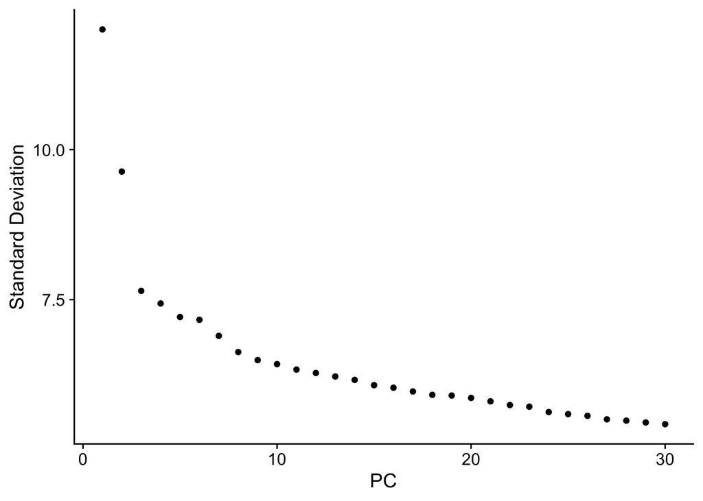

```r
ElbowPlot(object = seuset, ndims = 30)
```

```r
seuset <- RunUMAP(seuset, dims = 1:30, verbose = FALSE)

seuset <- FindNeighbors(seuset, dims = 1:30, verbose = FALSE)
seuset <- FindClusters(seuset, verbose = FALSE, resolution = 1)

seuset_vink <- seuset


umap.df <- as.data.frame(Embeddings(object = seuset, reduction = "umap")) %>%
  tibble::rownames_to_column(var="Cell") %>%
  cbind(seuset[[]])

# Subset based on sorted population
p1 <-
  ggplot(umap.df, aes(x=UMAP_1, y=UMAP_2, colour=condition)) +
  geom_point() +
  gghighlight(use_direct_label = FALSE) +
  theme(legend.position = "right") +
  facet_wrap(~condition) +
  theme_bw() +
  #scale_colour_manual(values=pal.pop2_sub) +
  labs(title="Highlighting the FACS population")

p1.1 <-
  ggplot(umap.df, aes(x=UMAP_1, y=UMAP_2, colour=Days)) +
  geom_point() +
  gghighlight(use_direct_label = FALSE) +
  theme(legend.position = "right") +
  facet_wrap(~condition) +
  theme_bw() +
  #scale_colour_manual(values=pal.pop2_sub) +
  labs(title="Highlighting the FACS population")

p1.2 <-
  ggplot(umap.df, aes(x=UMAP_1, y=UMAP_2, colour=Phase)) +
  geom_point() +
  gghighlight(use_direct_label = FALSE) +
  theme(legend.position = "right") +
  facet_wrap(~condition) +
  theme_bw() +
  #scale_colour_manual(values=pal.pop2_sub) +
  labs(title="Highlighting the FACS population")

p2 <-
  ggplot(umap.df, aes(x=UMAP_1, y=UMAP_2, colour=seurat_clusters)) +
  geom_point() +
  gghighlight(use_direct_label = FALSE) +
  theme(legend.position = "right") +
  facet_wrap(~seurat_clusters) +
  theme_bw() +
  #scale_colour_manual(values=pal.pop2_sub) +
  labs(title="Highlighting the in silico clusters")

png(file.path(outDir_Vink_fil, "UMAP_condition_afterFilter_01.png"), width=900, height=450)
p1
dev.off()
```

```r
png(file.path(outDir_Vink_fil, "UMAP_conditionDays_afterFilter_01.png"), width=900, height=450)
p1.1
dev.off()
```

```r
png(file.path(outDir_Vink_fil, "UMAP_conditionCC_afterFilter_01.png"), width=900, height=450)
p1.2
dev.off()
```

```r
png(file.path(outDir_Vink_fil, "UMAP_cluster_afterFilter_01.png"), width=1200, height=900)
p2
dev.off()
```

```r
png(file.path(outDir_Vink_fil, "EgGenes_Set1.png"), height = 1000, width = 1400)
FeaturePlot(seuset, features = gg1, pt.size = 1, ncol = 3)
dev.off()
```

```r
png(file.path(outDir_Vink_fil, "EgGenes_Set2.png"), height = 1000, width = 1400)
FeaturePlot(seuset, features = gg2, pt.size = 1, ncol = 3)
dev.off()
```

```r
png(file.path(outDir_Vink_fil, "EgGenes_Set3.png"), height = 1000, width = 1400)
FeaturePlot(seuset, features = gg3, pt.size = 1, ncol = 3)
dev.off()
```

```r
png(file.path(outDir_Vink_fil, "EgGenes_Set4.png"), height = 800, width = 1400)
FeaturePlot(seuset, features = gg4, pt.size = 1, ncol = 3)
dev.off()
```

#### Filtering cont

Re-run cluster

```r
su.markers <-
  FindAllMarkers(seuset, only.pos = TRUE, min.pct = 0.25, logfc.threshold = 0.25)
```

```r
write.csv(su.markers, file.path(outDir_Vink_fil, "MarkerGenes_filtered_01.csv"))

su.markers %>%
    group_by(cluster) %>%
    top_n(n = 10, wt = avg_log2FC) %>%
  pull(gene) %>% unique() -> top10


png(file.path(outDir_Vink_fil, "Top_ClusterDEG_DotPlot.png"), height = 700, width = 1500)
DotPlot(seuset, features = (top10), dot.scale = 6) + RotatedAxis() +
  scale_colour_gradient2(low = "#FF00FF", mid = "#000000", high = "#FFFF00")
```

[output not shown]

```r
dev.off()
```

Plot final sleection

```r
umap.df_full <- umap.df_full %>%
  mutate(isSel = if_else(Barcode %in% umap.df$Barcode, "Selected", "Discard"))

#SelCells <- umap.df %>%
#  dplyr::filter(UMAP_1 <=0 ) %>%
#  pull(Cell)

p2 <-
  ggplot(umap.df_full, aes(x=UMAP_1, y=UMAP_2, colour=isSel)) +
  geom_point() +
  #gghighlight(use_direct_label = FALSE) +
  theme(legend.position = "right") +
  #facet_wrap(~seurat_clusters) +
  theme_bw() +
  #scale_colour_manual(values=pal.pop2_sub) +
  labs(title="Highlighting the in silico clusters")

png(file.path(outDir_Vink_fil, "UMAP_cluster_Selected.png"), width=450, height=450)
p2
dev.off()
```

```r
#seuset_vink <- seuset[, seuset$Barcode %in% SelCells]

#seuset_vink <-
#  FindVariableFeatures(object = seuset_vink, selection.method = "vst", nfeatures = 2500)
# Scaling the data
#all.genes <- rownames(x = seuset_vink)
#seuset_vink <- ScaleData(object = seuset_vink, features = all.genes)

seuset_vink <- seuset
```

## Save

Now we have to exit the R-session due to memory limit. The integration will be performed in the next Rmarkdown file

Save all the filtered publicly availble data for future integration use

```r
save(seuset_nova, seuset_next, seu_nancy, seu_8.25_sub, seu_8.25_sub, seu_8.5_sub, seu_9.5_sub,
     seuset_zhou, seuset_hou, seuset_vink, seuset_pijuan,
     file=file.path(outData_dir, "ForIntegration_InHouse_Public.Rdata"))
```